# Wild plants of the coastal strand

Malcolm Ross

## 1. Introduction

Tropical coastal habitats are of two kinds, depending on whether or not fresh as well as salt water is available along the coastal strip. If fresh water is available, then a mangrove swamp may occur (chapter 6). If there is no fresh water or if mangroves are removed by human agency, a beach is formed.[^1]: In NW Island Melanesia beaches are usually sandy (rather than pebbly) and range from almost white, from the erosion of coral reefs and shells, to almost black, from the erosion of volcanic rocks. A beach creates an environment for coastal strand vegetation, which typically consists of three zones, the first two usually forming quite narrow bands:[^2]:

- herbaceous zone (§3);
- beach scrub (§4);
- littoral forest (§5).

There is sometimes also an underwater zone in the coastal shallows which is home to seagrasses and seaweeds.

Where the coast is gradually being built out by the accretion of sand, a succession of ridges develops, parallel to the beach. Ridges closer to the beach are typically about two metres high (Paijmans 1976: 27-28). The **herbaceous zone** begins at the high-tide mark and occupies the beach up to the first ridge. It has a cover of creeping plants which include *Ipomoea pes-caprae* (§3 .1), *Canavalia rosea* (syn. *Canavalia maritima*) (no reconstruction) and *Wedelia biflora* (§3.2), as well as grasses and sedges which include *Thuarea involuta* (ch.8, §3).

On their landward side the beach ridges merge into gently undulating flats which provide the environment for **beach scrub**. The border between the herbaceous zone and beach scrub is often vague and the two zones overlap. Beach scrub consists of shrubs like *Pemphis acidula* (§4.1.4) and *Scaevola taccada* (§4.1.5) and low-growing bushy-crowned trees like *Cordia subcordata* (§4.1.1), *Hernandia nymphaeifolia* (§4.1.2), *Hibiscus tiliaceus* (§4.1.3), *Thespesia populnea* (§4.1.6), *Tournefortia argentea* (§4.1.7) and *Vitex trifolia* (§4.1.8), often densely tangled with climbers like *Flagellaria indica* (§4.2.1). Beneath the shrubs is a ground layer of ferns, grasses, gingers and herbs which includes *Crinum asiaticum* (ch. 13, §6.6) (Mueller-Dombois & Fosberg 1998: 50).

Landwards, there is a transition, abrupt or gradual, from beach scrub to **littoral forest** (although it is common in NW Island Melanesia for littoral forest to have been displaced by coconut groves). This forest is often dominated by evergreen broadleaf trees like *Barringtonia asiatica* (§5.2), *Calophyllum inophyllum* (§5.3), *Heritiera littoralis* (ch.6, §4.4) and *Terminalia catappa* (ch.11, §2.4) (and in the Solomons *Cerbera manghas*, ch.6, §4.1) or the screwpine *Pandanus tectorius* (or on coral soil *Pandanus dubius*) (ch.11, §2.5) or sometimes *Casuarina equisetifolia* (§5.4). Where beach ridges have been eroded, littoral forest borders immediately on the beach, and *Barringtonia asiatica* (§5.2) predominates. Trees of lesser stature reported by Peekel (1984) in the littoral forest in New Ireland include *Adenanthera pavonina* (§5.1), *Guettarda speciosa* (§5.8) and *Pongamia pinnata* (§5.12). In the Solomons the lower storey includes *Hibiscus tiliaceus* (§4.1.3), *Diospyros* species (ch.7, §5.5), *Kleinhovia hospita* (ch. 7, §5. 7), *Ficus austrina* (no reconstruction), *Premna corymbosa* §5.13) and *Morinda citrifolia* (ch.13, §3.4) (Paijmans 1976:29-20, Henderson & Hancock 1988:321, Mueller-Dombois & Fosberg 1998: 50, 59, 70).

As the chapter numbers in the crossreferences above indicate, it is difficult to draw a line between littoral forest and lowland rain forest, as the two shade into each other. Trees which grow in lowland rain forest generally are mostly assigned to chapter 7. Certain trees of damper littoral forest also thrive on the landward margins of mangrove forests (*Heritiera littoralis*, *Cerbera manghas*) and are treated in chapter 6. *Terminalia catappa*, *Pandanus tectorius* and *Morinda citrifolia* fall under the rubric of tended or cultivated plants and are discussed in chapter 11.

From the perspective of linguistic reconstruction the shrubs and trees of the beach scrub zone and the littoral forest stand out because their names are quite easy to reconstruct, their Proto Oceanic (POc) names are often continuations of earlier forms, and they display continuity within Oceania. There are probably three main reasons for this. The first is simply that these plants have a very wide Pacific distrilbution, an obvious condition of continuity in naming. The second is probably that, being just behind the beach, they were easily accessible from people’s homes in beachside villages, and, thirdly, they also happen to be useful plants.

## 2. Coastal shallows

The coastal shallows are home to seagrasses and seaweeds and, if there is a reef, to any number of marine plants. Seagrasses are those families of Angiosperms (flowering plants) that spend their entire life cycle under water. Seaweeds, on the other hand, are algae.

POc had a generic term for mosses, algaes and seaweeds, namely *lumut or *limut (§4.6). Beyond this, comparative lexical material on these plants is thin, and only two further reconstructions are offered here. Glosses in the sources are vague, often not distinguishing between seagrass and seaweed. There are no species identifications.

The Tawala description below, ‘seaweed like kunai grass in appearance’, is a reasonable characterisation of seagrasses of the genus *Enhalus*, which is characterised by long narrow leaves (Peekel 1984: 42-44, Hviding 2005: 13) and this is the (weak) basis for the gloss of PNGOc *domu.

| **PNGOc** |  | *domu | ‘seagrass sp., perhaps *Enhalus*’ |
| --- | --- | --- | --- |
| NNG | Numbami | *do-domu* | ‘seaweed, sea grass’ |
| PT | Ubir | *dom* | ‘seaweed long species’ |
| PT | Gapapaiwa | *tom-tom* | ‘seaweed type’ |
| PT | Tawala | *tom-tom* | ‘seaweed like kunai grass in appearance’ |
| PT | Kilivila | *do-dom* | ‘seaweed’ |

The glosses of the items supporting the reconstruction of POc *karagʷam are both too vague and too varied to allow the denotation to be further pinned down. The Drehet gloss suggests a seaweed, Andra a seagrass. The Motu gloss is somewhat confusing, as *Fucus* is a genus of algae, not seagrass.

| **POc** |  | *karagʷam | ‘seaweed, seagrass’[^3] |
| --- | --- | --- | --- |
| Adm | Drehet | *kurak* | ‘seaweed’ |
| Adm | Andra | *korek* | ‘seagrass sp. growing on reef flat’ (unexpected vowels) |
| PT | Molima | *kalagoma* | ‘a seaweed’ |
| PT | Tawala | *yalegʷama* | ‘seaweed type, brown’ |
| PT | Muyuw | *yalig* | ‘seaweed used to paint canoes’ |
| PT | Motu | *alaga* | ‘seaweed like grass, *Fucus* sp.’ |
| MM | Nakanai | *lega* | ‘seaweed sp.’ |
| MM | Patpatar | *karaguo* | ‘seaweed’ |
| MM | Tolai | *kala-kalag* | ‘seaweed sp.’ |
| SES | Lau | *ʔalaga* | ‘seaweed’ |
| SES | Arosi | *ʔaraga* | ‘seaweed’ |
| Mic | Kiribati | *keaŋ* | ‘seagrass’ |

## 3. The herbaceous zone

### 3.1. *Ipomoea* spp., morning glory (Convolvulaceae)

Within the Evans’ *waRoc ‘vines and creepers’ taxon (ch.3, §4.4) there was apparently a subtaxon *puRe, which consisted of beach creepers. Clark (1996) takes the PEOc reflex to have denoted shore creepers of the genus *Convolvulus*. The evidence for this in the cognate set below is at first sight thin. However, there is a strong tendency in the botanical literature for *Ipomoea* species (‘morning glory’) to have synonyms in the genus *Convolvulus*, and it is likely that some, if not all, of the *Convolvulus* glosses below denote *Ipomoea* species. It is thus possible that POc *puRe prototypically denoted *Ipomoea grandiflora* (syn. *Ipomoea tuba*, *Convolvulus tuba*, *Calonyction grandiflorum*) and *Ipomoea pes-caprae* (Figure 5.1, left), beach creepers with trumpet-like flowers, white and purple respectively, commonly found on beaches in the Bismarck Archipelago (Peekel 1984: 461). Eastern Polynesian reflexes reflect a shift in denotatum to the gourd *Lagenaria siceraria* (ch.13, §7.1).

No reconstruction can be made for another beach creeper, *Canavalia rosea* (syn. *Canavalia maritima*), which typically co-occurs with *Ipomoea pes-caprae*. It is possible that it was included, at least at some locations, in the *puRe subtaxon.

| **POc** |  | *puRe | ‘taxon of beach creepers; perhaps prototypically *Ipomoea grandiflora* and *Ipomoea pes-caprae*’ |
| --- | --- | --- | --- |
| Adm | Lou | *pʷi-pʷi* | ‘vine which grows on the sand’ |
| NNG | Kairiru | *wul (kabuk)* | ‘wax gourd, *Benincasa hispida*’ |
| PT | Muyuw | *(igina)pʷey* | ‘*Ipomoea pes-caprae*’ |
| MM | Nakanai | *vule* | ‘Crinum sp.’ |
| MM | Kia | *fu-fure* | ‘*Ipomoea pes-caprae*’ (W. McClatchey, pers. comm.) |
| MM | Kokota | *fu-fure* | ‘a flowering plant, grows as a littoral creeper’ |
| MM | Gao | *fu-fure* | ‘*Ipomoea pes-caprae*’ (W. McClatchey, pers. comm.) |
| SES | Lau | *fule-fule* | ‘sp. creeper on the shore’ |
| SES | Arosi | *hure* | ‘beach creeper, *Convolvulus* sp.’ |
| SES | Sa’a | *hule* | ‘*Convolvulus* sp. growing on beach.’ |
| NCV | Uripiv | *na-wu-wu (ne dis)* | ‘creeper growing at seashore’ (*dis* ‘sea’) |
| NCV | Paamese | *hua-hue* | ‘beach morning glory’[^4] |
| NCV | Lewo | *(ma)wo-we* | ‘*Ipomoea* sp.’ |
| SV | Kwamera | *nə-fua* | ‘beach vine sp. with yellow trumpet-shaped flowers’[^5] |
| SV | Anejom̃ | *no-hou* | ‘vine sp. on beach with purple flower’[^6] |
| NCal | Xârâcùù | *kʷe* | ‘gourd’ |
| Pn | Tongan | *fue* | ‘generic term for vines’ (Whistler 1991b: 35) |
| Pn | Niuean | *fue* | ‘creeping vine, *Merremia peltata*’ |
| Pn | East Futunan | *fue* | ‘*Canavalia maritima*’ |
| Pn | Rennellese | *hue* | ‘*Ipomoea pes-caprae*’ |
| Pn | Tikopia | *fue* | ‘a beach vine’ |
| Pn | West Futunan | *fue* | ‘sweet potato sp.’ |
| Pn | Samoan | *fue* | ‘generic for vines and creepers’ (Whistler 2000: 166) |
| Pn | Tuvalu | *fue* | ‘*Canavalia maritima*’ |
| Pn | Kapingamarangi | *hue* | ‘*Ipomoea alba*’ |
| Pn | Tokelauan | *fue* | ‘a vine, *Ipomoea macrantha*’ |
| Pn | Tuamotuan | *hue* | ‘gourd’ |
| Pn | Tuamotuan | *(poo)hue* | ‘*Convolvulus* sp.’ |
| **PEPn** |  | *fue | ‘gourd, *Lagenaria siceraria*’ |
| Pn | Tahitian | *hue* | ‘gourd, calabash’ |
| Pn | Rapanui | *hue* | ‘gourd, *Lagenaria siceraria*’ |
| Pn | Rarotongan | *ʔue* | ‘gourd, *Lagenaria siceraria*’ |
| Pn | Māori | *hue* | ‘gourd, *Lagenaria siceraria*’ |

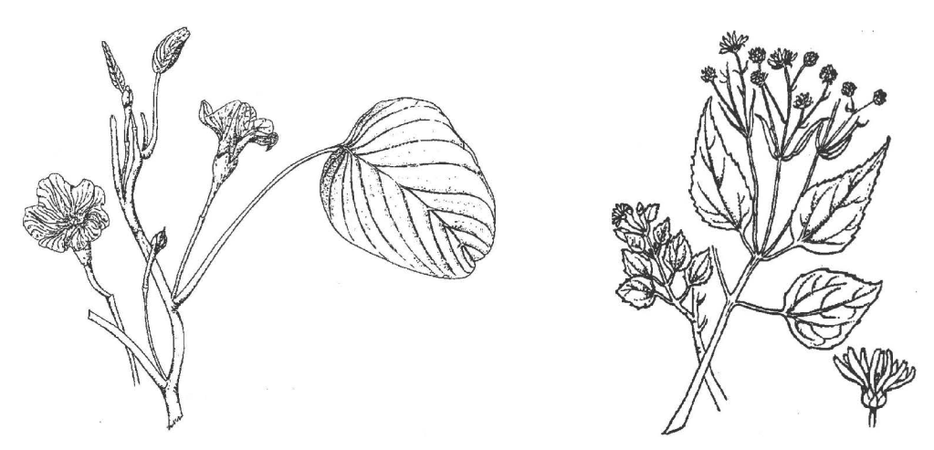

**Figure 5.1:** **Left** *Ipomoea pes-caprae*, morning glory. **Right** *Wedelia biflora*.

### 3.2. *Wedelia biflora* (syn. *Wollastonia biflora*) (Asteraceae)

*Wedelia biflora* (Figure 5.1, right) is a herbaceous or half-shrubby coastal plant, usually 1.5-2.5 m tall, with yellow flowers. On the beach it sometimes forms impenetrable thickets, but it also occurs in the littoral forest, where it climbs as high as 6m (Peekel 1984: 561).

The leaves are filled with a tasty milk-like sap, and Tangga speakers (offshore east of southern New Ireland) boil and eat them (Bell 1947: 244)). At Marovo the leaves are an ingredient in cures for stomach ache (Hviding 2005: 108).

The following comparison is due to Blust (ACD), who associates it with PMP *qatay ‘liver’, since sources from the Philippines and northern Sulawesi suggest that the plant owes its name to the fact that its leaves are shaped like a pig’s liver.

Bender et al. (2003) reconstruct PChk *adɨ-adɨ ‘*Wedelia biflora*’. It is hard to believe that this is not associated with the reconstruction above, but this association must be by borrowing (perhaps from Yapese), as the PChk form would reflect POc †*(q)a(s,j)u-(q)a(s,j)u, not *qate-qate.

| **PMP** |  | *qatay-qatay | ‘a climbing plant, *Wedelia biflora*’ (ACD) |
| --- | --- | --- | --- |
| **POc** |  | *(qate-)qate | ‘*Wedelia biflora*’ |
| Yap | Yapese | *ʔæaθ* | ‘flower of a type of plant’ |
| Pn | Tongan | *ate* | ‘shrub, *Wedelia biflora*’ (for expected †*ʔate*) |
| Pn | West Uvea | *ate* | ‘shrub, *Wedelia* sp.’ |
| Pn | Anutan | *ate* | ‘plant spp., *Wedelia biflora*, *Adenostemma lavenia*’ |
| Pn | Samoan | *ate-ate* | ‘shrub, *Wedelia biflora*’ |

cf. also:

|  | PChk | *adɨ-adɨ | ‘*Wedelia biflora*’(Bender et al. 2003) |
| --- | --- | --- | --- |
| Mic | Mortlockese | *ɛtiyet* | ‘*Wedelia biflora*’ |
| Mic | Chuukese | *ətɨwət* | ‘*Wedelia biflora*’ |
| Mic | Puluwatese | *yætiyæt* | ‘*Wedelia biflora*’ |
| Mic | Satawalese | *yatiyat* | ‘*Wedelia biflora*’ |
| Mic | Ulithian | *yaθyəθ* | ‘*Wedelia biflora*’ |

## 4. Beach scrub

### 4.1. Woody shrubs and small trees

#### 4.1.1. *Cordia subcordata*, kerosene wood, island walnut, sea trumpet, Pacific rosewood, P *kerasin wud*, B *burao blong solwata* (Boraginaceae)

A twisted shore tree 8-15 m tall, *Cordia subcordata* (Figure 5.2, left) is well known for its very strong black-veined heartwood, which may remain as a skeleton after the rest of a dead tree has rotted away (W. McClatchey, pers. comm.). It occurs in varieties with orange and yellow flowers (Peekel 1984: 471, Hviding 2005: 131).

Its wood is lightweight but durable. In the western Solomons, in Vanuatu and on Waya Island it is used for carving (Gowers 1976: 56, Hviding 2005: 131, Gardner & Pawley 2006, Friday & Okano 2006). In earlier times the Marovo also used it for house posts, but its use in construction seems never to have been widespread. On New Ireland, however, the ceremonial V-shaped entrance to a men’s house was always made of *Cordia subcordata* (Record 1945). In Tonga it was used for carving and for construction (Whistler 1991b: 108). Gowers (1976: 56) and Capell (1941) report that its sap served as an adhesive in Vanuatu and Fiji.

POc *kanawa(n), *toRu and *jasi and PWOc *nagi are all reconstructable, but contrasts in meaning are unclear.

| **PMP** |  | *kanawa | ‘*Cordia* spp.’ (ACD) [^7] |
| --- | --- | --- | --- |
| **POc** |  | *kanawa(n) | ‘*Cordia subcordata*’ |
| NNG | Kove | *kanau* | ‘*Cordia subcordata*’ (Chowning 2001: 83) |
| PT | Misima | *ganawan* | ‘*Cordia subcordata*’ |
| MM | East Kara | *keno* | ‘*Cordia subcordata*’ |
| MM | Patpatar | *kanawa* | ‘*Cordia subcordata*’ |
| MM | Tolai | *kanao* | ‘*Cordia subcordata*’ |
| Mic | Kiribati | *kanawa* | ‘*Cordia subcordata*’ |
| Mic | Mokilese | *kanaw* | ‘tree sp.’ |
| Mic | Woleaian | *xarüw* | ‘*Cordia subcordata*’ |
| Mic | Chuukese | *anaw* | ‘*Cordia subcordata*’ |
| Mic | Puluwatese | *yānaw* | ‘*Cordia subcordata*’ |
| Fij | Wayan | *nawa-nawa* | ‘*Cordia subcordata*’ |
| Fij | Bauan | *nawa-nawa* | ‘*Cordia subcordata*’ |
| Pn | Tongan | *(pua tau)kanave* | ‘*Cordia subcordata*’ |
| Pn | East Uvean | *kanava* | ‘*Cordia subcordata*’ |
| Pn | East Futunan | *kānava* | ‘tree sp. with black wood and small red flower, found at Alofi’ |
| Pn | Samoan | *(tau)anave* | ‘*Cordia subcordata*’ |
| Pn | Tokelauan | *tānava* | ‘*Cordia subcordata*’ |
| Pn | Nukuoro | *ganava* | ‘*Cordia subcordata*’ |
| Pn | Nukuria | *ganava* | ‘*Cordia subcordata*’ |

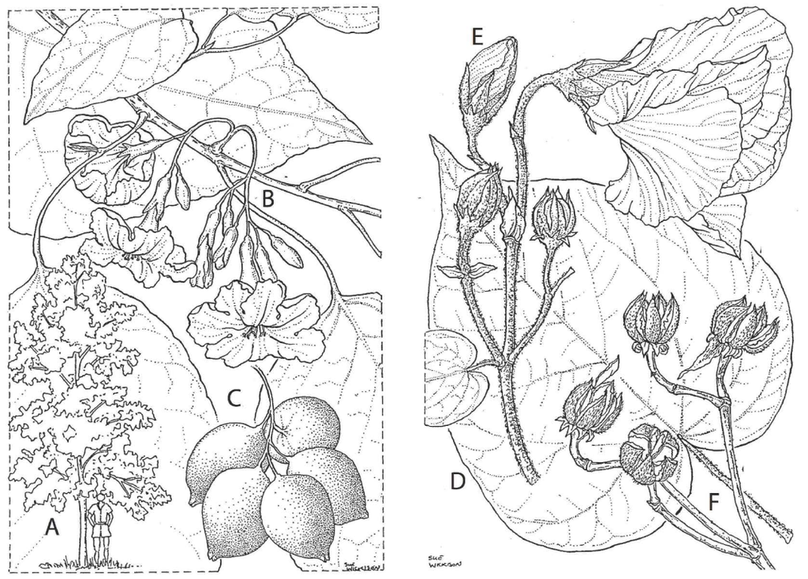

**Figure 5.2:** **Left** *Cordia subcordata*, kerosene wood: **A**, tree; **B**, small branch with flowers and leaves; **C**, fruit cluster **Right** *Hibiscus tiliaceus*, cotton wood: **D**, leaf; **E**, shoot with flower; **F**, matured over-ripe fruit cluster.

| **POc** |  | *toRu | ‘*Cordia subcordata*’ |
| --- | --- | --- | --- |
| MM | Nehan | *to-tor* | ‘*Cordia subcordata*’ |
| MM | Petats | *to-tol* | ‘*Cordia subcordata*’ |
| Fij | Wayan | *tou-tou* | ‘tree of coastal slopes and rocky places inland: *Gyrocarpus americanus*’ |
| Fij | Bauan | *tou* | ‘*Cordia aspera*, sap used as a paste’ |
| Pn | Tongan | *tou* | ‘*Cordia aspera*’ |
| Pn | East Uvean | *tou* | ‘*Cordia aspera*’ |
| Pn | Tikopia | *tou* | ‘unidentified tree with soft light timber, no economic use’ |
| Pn | Samoan | *tou* | ‘*Cordia aspera*’ |
| Pn | Tongarevan | *tou* | ‘*Cordia subcordata*’ |
| Pn | Rarotongan | *tou* | ‘*Cordia subcordata*’ |
| Pn | Tahitian | *tou* | ‘*Cordia subcordata*’ |
| Pn | Tuamotuan | *tou* | ‘*Cordia subcordata*’ |
| Pn | Hawaiian | *kou* | ‘*Cordia subcordata*’ |
| Pn | Marquesan | *tou* | ‘*Cordia subcordata*’ |

The term *jasi is reconstructed for PCEMP and POc (rather than PEOc, as the data here imply) because there appears to be an external cognate in Timorese *(nonwai) tasi* ’_Cordia_s ubcordata’ (Heyne 1950: 1306).

| **PCEMP** |  | *jasi | ‘*Cordia subcordata*’ |
| --- | --- | --- | --- |
| **POc** |  | *jasi | ‘*Cordia subcordata*’ |
| SES | Kwara’ae | *(fofo)tasi* | ‘*Cordia subcordata*’ |
| NCV | Nduindui | *(fifai) na-tahi* | ‘*Cordia subcordata*’ |
| **PPn** |  | *tahi | ‘heartwood, including that of *Cordia subcordata*’ |
| Pn | Tongan | *tahi* | ‘hard heart or solid centre of certain kinds of tree’ |
| Pn | East Uvean | *tahi* | ‘old (of wood)’ |
| Pn | Samoan | *tai* | ‘heart of a tree’ |
| Pn | Tuvalu | *tai(ki)* | ‘heartwood’ |
| Pn | Tokelauan | *tai(tea)* | ‘white wood of *Cordia subcordata*’ |
| Pn | Tokelauan | *tai(uli)* | ‘dark wood of *Cordia subcordata*’ |
| Pn | Rarotongan | *tai(ki)* | ‘heartwood’ |
| Pn | Māori | *tai(ki)* | ‘heartwood’ |

| **PWOc** |  | *nagi | ‘*Cordia* sp.’ |
| --- | --- | --- | --- |
| PT | Muyuw | *(a)nag* | ‘*Cordia* sp.’ |
| MM | Nduke | *na-nagi* | ‘*Cordia* sp.’ |
| MM | Marovo | *nagi-nagi* | ‘*Cordia subcordata*’ |

#### 4.1.2. *Hernandia nymphaeifolia* (syn. *Hernandia peltata*), sea hearse tree, lantern tree, B *nambirimbiri*, *napiripiri*, *bluwud* (Hernandiaceae)

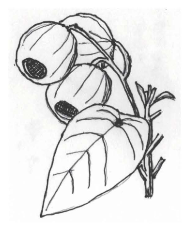

**Figure 5.3:** *Hernandia nymphaeifolia*, sea hearse tree

Peekel (1984: 192) describes *Hernandia nymphaeifolia* as ‘one of the most frequent beach trees’ in New Ireland. It is a small tree with hard white wood, white flowers and spherical white fruit about 3cm in diameter which ripen to pink (Gowers 1976: 85).

The Nakanai of New Britain and people in parts of Vanuatu use the trunk for making canoe hulls. The Nakanai also use the wood for hourglass drums (Floyd 1954, Gowers 1976: 85).

Bennett (n.d.) comments that at Biliau (north coast of New Guinea) the flowers are used on a hook to attract fish when one is fishing from a moving boat.

On Waya Island (Fiji) the flowers are said to have provided medicine for asthma (Gardner & Pawley 2006), and Gowers also reports that it was held to have medicinal properties in Vanuatu.

There is some evidence that for early Oceanic speakers *Hernandia nymphaeifolia* and *Thespesia populnea* (§4.1.6) formed a taxon.[^8]: Both are small shore trees and both have hard wood that is used for hourglass drums. In Lau the regular reflex of POc *biRi-biRi ‘*Hernandia nymphaeifolia*’ denotes ‘*Thespesia populnea*’. In Wayan Fijian the same is true of a borrowed reflex of *biRi-biRi. The Kiribati reflex of *biRi-biRi appears to denote both tree species.

The Nduke and Roviana reflexes appear to denote *Excoecaria agallocha* (ch.6, §4.3), the leaves of which resemble those of *Hernandia nymphaeifolia* (W. McClatchey, pers. comm.).

Clark (1996) takes the *-r- of PNCV *biri-biri below to reflect POc *-r-, but loss of the rhotic in PPn *pipi points to POc *-R-. Recent work by Lynch (2007) shows that PNCV *-r- may reflect either POc *-r- or POc *-R-, confirming that the POc form was almost certainly *biRi-biRi. There is a margin of uncertainty because the Polynesian forms have short *i* where long vowels are expected, and the authors of POLLEX suggest that this may reflect borrowing.

The Seimat and Micronesian forms reflect POc †*biŋi-biŋi rather than *biRi-biRi. It is possible that the Seimat form represents a borrowing from a Micronesian language, but PMic *-ŋ- remains unexplained.

| **POc** |  | *biRi-biRi | ‘*Hernandia nymphaeifolia*’ (PNCV Clark 1996; PEOc Geraghty 1990) |
| --- | --- | --- | --- |
| Adm | Seimat | *biŋi-biŋi* | ‘*Hernandia ovigera*’ (Sorensen 1950) |
| NNG | Bing | *pir-pir* | ‘tree sp. (with white flowers; grows beside the sea)’ |
| MM | East Kara | *vi-vi* | ‘*Hernandia nymphaeifolia*’ |
| MM | Patpatar | *bir-bir* | ‘*Hernandia nymphaeifolia*’ |
| MM | Tolai | *(palu)bir* | ‘*Hernandia nymphaeifolia*’ |
| MM | Sursurunga | *bir-bir* | ‘large tree that grows on sand’ |
| MM | Nehan | *bir-bir* | ‘*Hernandia nymphaeifolia*’ |
| MM | Kubokota | *biri-biri* | ‘a tree that grows on the shore, whose leaves are used as medicine for stings from certain fish’ |
| MM | Nduke | *bi-biri* | ‘tree of mangrove areas, sap injures the eyes’ (perhaps *Excoecaria agallocha*) |
| MM | Roviana | *biri-biri* | ‘beach tree, sap injures the eyes’ (perhaps *Excoecaria agallocha*) |
| **PEOc** |  | *biRi-biRi | ‘k.o. shore tree, *Hernandia nymphaeifolia*’ |
| SES | Gela | *bi-bili* | ‘k.o. tree’ |
| SES | Lau | *bili-bili* | ‘tree sp., *Thespesia populnea*’ |
| SES | Arosi | *biri-biri* | ‘tree sp.’ |
| **PNCV** |  | *biri-biri | ‘k.o. shore tree, *Hernandia nymphaeifolia*’ |
| NCV | Mwotlap | *biy-biy* | ‘*Hernandia nymphaeifolia*’ |
| NCV | Mota | *pir-pir* | ‘tree sp.’ |
| NCV | Ambae | *biri-biri* | ‘*Hernandia nymphaeifolia*’ |
| NCV | Raga | *biri-biri* | ‘*Hernandia nymphaeifolia*’ |
| NCV | Paamese | *viri-viri* | ‘*Hernandia nymphaeifolia*’ |
| NCV | Lewo | *(pur)pel-pele* | ‘*Hernandia nymphaeifolia*’ |
| NCV | Namakir | *bi-bir* | ‘*Hernandia nymphaeifolia*’ |
| NCV | Nguna | *na-peperi* | ‘*Hernandia nymphaeifolia*’ |
| NCV | South Efate | *na-ipir* | ‘*Hernandia nymphaeifolia*’ |
| **PMic** |  | *piŋi-piŋi | ‘*Hernandia nymphaeifolia*’ |
| Mic | Kiribati | *piŋi-piŋ* | ‘*Thespesia populnea* and probably *Hernandia nymphaeifolia*’ |
| Mic | Marshallese | *piŋ-piŋ* | ‘*Hernandia nymphaeifolia*’ |
| **PCP** |  | *bībī | ‘*Hernandia* spp.’ |
| Fij | Wayan | *wiri-wiri* | ‘*Thespesia populnea*’ (borrowing: exp form is †*bībī*) |
| **PPn** |  | *pi-pi | ‘k.o. shore tree, *Hernandia nymphaeifolia*’ (exp form is †*pīpī) |
| Pn | Niuean | *pi-pi* | ‘a large tree, *Hernandia moerenhoutiana*’ |
| Pn | Tongan | *pi-pi (failolo)* | ‘*Atuna racemosa*’ |
| Pn | East Futunan | *pi-pi* | ‘tree with a soft black interior like a fir’ |
| Pn | Samoan | *pi-pi* | ‘tree, *Hernandia moerenhoutiana*’ |

cf. also:

| PT | Misima | *bi-biu* | ‘*Hernandia nymphaeifolia*’ |
| --- | --- | --- | --- |
| Fij | Rotuman | *pi-pi* | ‘*Atuna racemosa*’ (W. McClatchey, pers. comm.) |

| **PROc** |  | *buavu | ‘*Hernandia* sp.’ |
| --- | --- | --- | --- |
| NCal | Nyelâyu | *pʰoap* | ‘*Hernandia ovigera*’ |
| Fij | Wayan | *buevu* | ‘*Hernandia nymphaeifolia*’ |

#### 4.1.3. *Hibiscus tiliaceus*, beach hibiscus, TP *mangas*, P, B *burao* (Malvaceae)

*Hibiscus tiliaceus* is a small sprawling, tangled shore tree with small girth, a branching trunk and pale yellow flowers (Figure 5.2, right). It grows 5-15 m tall (Peekel 1984: 364, Henderson & Hancock 1988: 161). Barrau (1965) reports that the bark was eaten in New Caledonia, and almost every source agrees that it provides fibre to make cordage, mats and nets (e.g. Floyd 1954, O’Collins & Lamothe 1989, Whistler 1991b: 29).

The POc term for *Hibiscus tiliaceus* was *paRu. Blust (ACD) suggests that it is reflected in terms for ‘tie’ like Bauan *vau* ‘tie, bind’ and Samoan *fau* ‘bind, lash together’, but it is now clear that these terms reflect POc *paqu(s), *paqus-i- ‘bind, lash; construct canoe by tying together’ (vol.1, ch.9, §10).

| **PMP** |  | *baRu | ‘*Hibiscus tiliaceus*’ (ACD) |
| --- | --- | --- | --- |
| **POc** |  | *paRu | ‘*Hibiscus tiliaceus*’ |
| Adm | Lou | *po* | ‘*Hibiscus tiliaceus*’ |
| NNG | Kove | *vahu* | ‘*Cordia subcordata*’ |
| NNG | Gitua | *paru* | ‘*Hibiscus tiliaceus*’ |
| NNG | Tami | *pa-palau* | ‘*Hibiscus tiliaceus*’ |
| NNG | Kairiru | *fyar* | ‘*Hibiscus*’ |
| PT | Muyuw | *(ayo)vay* | ‘*Hibiscus tiliaceus*’ (F. Damon, pers. comm.) |
| PT | Hula | *vatu* | ‘*Hibiscus tiliaceus*’ |
| MM | Bola | *varu* | ‘*Hibiscus tiliaceus*’ |
| MM | East Kara | *fai* | ‘*Hibiscus tiliaceus*’ |
| MM | Tolai | *va[r]-var* | ‘k.o. tree, the bark of which is used as string’ |
| MM | Varisi | *varu* | ‘*Hibiscus tiliaceus*’ (W. McClatchey, pers. comm.) |
| MM | Babatana | *varu* | ‘*Hibiscus tiliaceus*’ |
| MM | Nduke | *varu* | ‘*Hibiscus tiliaceus*’ |
| MM | Roviana | *varu* | ‘*Hibiscus tiliaceus*’ |
| MM | Marovo | *(leru) varu* | ‘a forest tree growing near rivers, *Agathis macrophylla*’ (*leru* ‘*Hibiscus tiliaceus*’) |
| TM | Äiwoo | *(nuo)po* | ‘*Hibiscus tiliaceus*’ |
| **PEOc** |  | *paRu | ‘*Hibiscus tiliaceus*’ |
| SES | Gela | *valu* | ‘tree sp.’ |
| SES | Lengo | *valu* | ‘*Hibiscus tiliaceus*’ |
| SES | Longgu | *valu* | ‘*Hibiscus tiliaceus*’ |
| SES | ’Are’are | *haru* | ‘shrub sp.’ |
| SES | Arosi | *haru* | ‘tree sp.’ |
| NCV | Ambae | *vae* | ‘*Hibiscus tiliaceus*’ |
| NCV | Mota | *varu* | ‘*Hibiscus tiliaceus*’ |
| NCV | Araki | *(vi)ða* | ‘*Hibiscus tiliaceus*’ |
| NCV | Naman | *nə-veve* | ‘*Hibiscus tiliaceus*’ |
| NCV | Tape | *vive* | ‘*Hibiscus tiliaceus*’ |
| NCV | Uripiv | *vava* | ‘*Hibiscus tiliaceus*’ |
| NCV | Paamese | *vea-vee* | ‘*Hibiscus tiliaceus*’ |
| **PSV** |  | *nə-vau | ‘*Hibiscus tiliaceus*’ (Lynch 2001c) |
| SV | Sye | *n-vau* | ‘*Hibiscus tiliaceus*’ |
| SV | Kwamera | *ne-vo* | ‘*Hibiscus tiliaceus*’ |
| SV | Anejom̃ | *n-hau* | ‘*Hibiscus tiliaceus*’ |
| NCal | Iaai | *vɨɨu* | ‘*Hibiscus tiliaceus*’ |
| NCal | Xârâcùù | *pe* | ‘*Hibiscus tiliaceus*’ |
| NCal | Nyelâyu | *paɣi* | ‘*Hibiscus tiliaceus*’ |
| **PCP** |  | *vau | ‘*Hibiscus tiliaceus*’ |
| Fij | Rotuman | *hau* | ‘*Hibiscus tiliaceus*’ |
| Fij | Wayan | *vau* | ‘*Hibiscus tiliaceus*, *Kleinhovia hospita*’[^9] |
| Fij | Bauan | *vau* | ‘*Hibiscus tiliaceus*’ |
| Pn | Niuean | *fou* | ‘*Hibiscus tiliaceus*’ |
| Pn | Tongan | *fau* | ‘*Hibiscus tiliaceus*’ |
| Pn | Pukapukan | *wau* | ‘tree sp. whose bark is used for cordage’ |
| Pn | Rennellese | *hau* | ‘*Hibiscus tiliaceus*’ |
| Pn | Tikopia | *fau* | ‘*Hibiscus tiliaceus*’ |
| Pn | Emae | *fau* | ‘*Hibiscus tiliaceus*’ |
| Pn | Samoan | *fau* | ‘*Hibiscus tiliaceus*’ |
| Pn | Rarotongan | *ʔau* | ‘*Hibiscus tiliaceus*’ |
| Pn | Hawaiian | *hau* | ‘*Hibiscus tiliaceus*’ |

| **PEOc** |  | *pakalo, *pʷakala | ‘*Hibiscus* sp.’ |
| --- | --- | --- | --- |
| MM | Kokota | *fayalo* | ‘*Hibiscus* sp.’ |
| **PSES** |  | *vaɣalo | ‘*Hibiscus tiliaceus*’ |
| SES | Bugotu | *vaɣaðo* | ‘*Hibiscus tiliaceus*’ (Henderson and Hancock 1988) |
| SES | Gela | *vaɣalo* | ‘tree sp.’ |
| SES | Birao | *vahalo* | ‘*Hibiscus tiliaceus*’ |
| SES | Kwara’ae | *faʔalo,faʔola* | ‘*Hibiscus tiliaceus*’ (Henderson and Hancock 1988) |
| SES | Dori’o | *faʔalo* | ‘*Hibiscus tiliaceus*’ |
| SES | Arosi | *haʔaro* | ‘*Hibiscus tiliaceus*’ |
| SES | Kahua | *haʔaro* | ‘*Hibiscus tiliaceus*’ |
| **PNCV** |  | *bʷakala | ‘*Hibiscus* sp.’ (Clark 1996) |
| NCV | Mwotlap | *na-bʷɣal* | ‘*Hibiscus* rosa-sinensis’ |
| NCV | Mota | *bʷaɣala* | ‘flowering hibiscus of many varieties’ |
| NCV | Naman | *belag* | ‘*Hibiscus tiliaceus*’ (metathesis) |
| NCV | Neve’ei | *ne-bʷelagu* | ‘*Hibiscus tiliaceus*’ (metathesis) |
| NCV | Avava | *balaɣa* | ‘*Hibiscus tiliaceus*’ (metathesis) |
| NCV | Larëvat | *balgo* | ‘*Hibiscus tiliaceus*’ (metathesis) |
| NCV | South Efate | *na-pʷkal* | ‘*Hibiscus* rosa-sinensis’ |
| **PSV** |  | *na-bʷaz | ‘*Hibiscus* sp.’ (Lynch 2001c) |
| SV | Anejom̃ | *n-pʷaz* | ‘*Hibiscus* sp.’ |
| NCal | Pije | *pakēla* | ‘*Hibiscus* abelmoschus’ |
| NCal | Nêlêmwa | *paxēla* | ‘*Hibiscus* abelmoschus’ |

cf. also:

| SES | Lau | *fakaso* | ‘*Hibiscus tiliaceus*’ |
| --- | --- | --- | --- |
| SES | Kwara’ae | *fakusu* | ‘*Hibiscus tiliaceus*’ |

#### 4.1.4. *Pemphis acidula* (Lythraceae)

*Pemphis acidula* is a small twisted beach tree (Figure 5.4, left) with very hard, tough wood used at Marovo to make tools such as pestles, husking sticks and weapons (Hviding 2005: 131), in Tonga for tool handles and house parts (Whistler 1991b: 39) and in Tahiti to make combs (POLLEX). Its distribution seems to be patchy: it is not mentioned by Peekel (1984) for the Bismarcks nor by Borrell (1989) for Kairim (Schoutens). Will McClatchey (pers. comm.) suggests that its distribution across Oceania was once quite uniform but that it was so useful that it was pushed to extinction in some places. The reconstruction of POc *ŋiRac is unproblematic as its reflexes are regular.

| **PMP** |  | *ŋiRaj | ‘*Pemphis acidula*’[^10] |
| --- | --- | --- | --- |
| **POc** |  | *ŋiRac | ‘*Pemphis acidula*’ (Geraghty 1990: PEOc *ŋiRa) |
| PT | Misima | *nila-nila* | ‘*Pemphis acidula*’ |
| MM | Nehan | *gihes* | ‘*Pemphis acidula*’ |
| MM | Nduke | *ŋirasa* | ‘*Pemphis acidula*’ |
| MM | Marovo | *ŋirasa* | ‘*Pemphis acidula*’ |
| MM | Kia | *ŋi-ŋirasa* | ‘*Pemphis acidula*’ (W. McClatchey, pers. comm.) |
| NCV | Uripiv | *ne-ŋir* | ‘*Pemphis acidula*’ |
| SV | Anejom̃ | *ne-ŋiye* | ‘*Pemphis acidula*’ |
| Mic | Kiribati | *ŋea* | ‘*Pemphis acidula*’ |
| Mic | Marshallese | *(kə)ŋe* | ‘*Pemphis acidula*’ |
| Mic | Chuukese | *(ē)ŋi* | ‘*Pemphis acidula*’ |
| Mic | Woleaian | *(xai)ŋiy* | ‘*Pemphis acidula*’ |
| **PCP** |  | *ŋi(a)-ŋia | ‘*Pemphis acidula*’ |
| Fij | Bauan | *ŋi-ŋia* | ‘*Pemphis acidula*’ |
| Fij | Wayan | *ŋia-ŋia* | ‘*Pemphis acidula*’ |
| Pn | Tongan | *ŋi-ŋie* | ‘shore shrubs or small trees *Pemphis acidula* and *Suriana maritima*’ |
| Pn | Niuean | *ŋi-ŋie* | ‘*Pemphis acidula*’ |
| Pn | Rennellese | *ŋi-ŋie* | ‘shrub sp. growing on coastal ledges.’ |
| Pn | Pukapukan | *ŋi-ŋie* | ‘tree sp.’ |
| Pn | Sikaiana | *n-nie* | ‘a plant with strong wood’ |
| Pn | Takuu | *n-nie* | ‘*Pemphis acidula*’ |
| Pn | Tokelauan | *ŋa-ŋie* | ‘*Pemphis acidula*’ |
| Pn | Mangaia | *ŋa-ŋie* | ‘a littoral shrub’ |
| Pn | Tahitian | *(ā)ʔie* | ‘*Pemphis acidula*’ |
| Pn | Tuamotuan | *ŋie-ŋie* | ‘*Pemphis acidula*’ |

#### 4.1.5. *Scaevola taccada* (syn. *Scaevola koenigii*, *Scaevola sericea*, *Scaevola frutescens*), B *haf flaoa* (Goodeniaceae)

Peekel (1984: 553) describes *Scaevola taccada* as a ‘stiffly erect shrub with finger-thick fleshy green twigs, 2-4m tall’ and ‘common, on sandy beaches’ (Figure 5.4, middle). The shrubs grow in dense clusters near the beach (Hviding 2005: 122). It is probably the best distributed plant on the Pacific islands, found on the smallest islets and the largest islands (W. Mc-Clatchey, pers. comm.). The light green leaves are somewhat succulent with a waxy covering and are alternately arranged along the stem. The white or cream flowers, often with purple streaks, are 8-12 mm long and have a pleasant smell. All five petals are on one side of the flower, so that they look as if they have been torn in half (hence the Bislama term *haf flaoa*). The fruit of *Scaevola taccada* are fleshy white oblong berries of varying size, the smallest about 1 cm long.

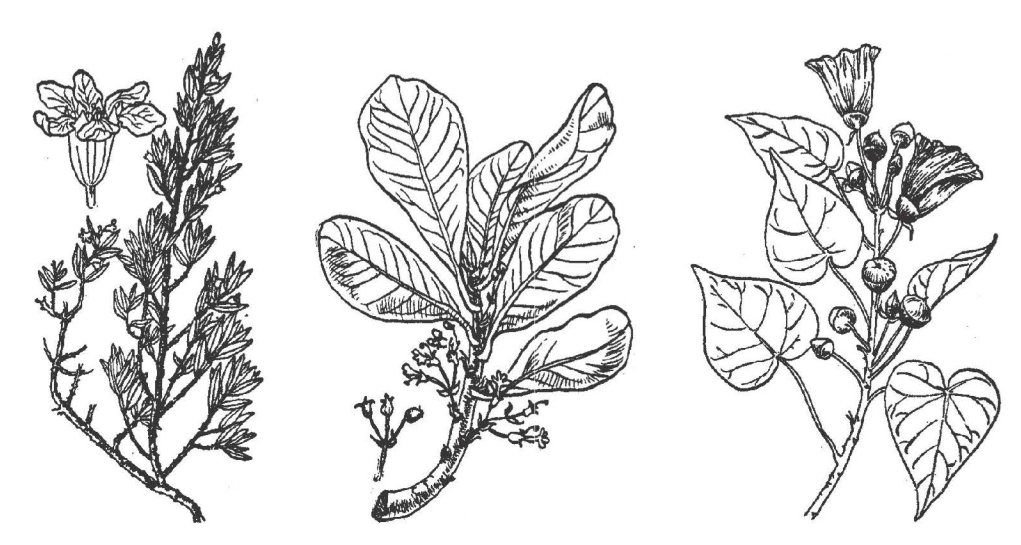

**Figure 5.4:** **Left** Pemphis-acidula. **Middle** *Scaevola taccada*. **Right** *Thespesia populnea*.

On Lihir the leaves are squeezed in salt water and the resultant sap is used for various medicinal purposes. The leaves are heated over the fire and rubbed on the skin to relieve pain in joints, bones, and muscles (S. Foale 2001). The stem bark was used for medicinal purposes in Tonga (Whistler 1991b: 38). At Marovo the leaves are used during fishing trips to shield the catch from the sun and to parcel up food. Newly broken leaves and branches provide evidence that a turtle has made a nest nearby (Hviding 2005: 122).

PEMP *nasu-nasu is reconstructed on the basis of the Oceanic data here, plus Weda (S Halmahera) *nesnas* and Biak *anas*, both ‘*Scaevola taccada*’ (Heyne 1950: 1428). It happens that *-u is lost from POc *CVC_u_ forms in Pak and in the Western Oceanic and Southern Vanuatu languages in which reflexes occur. Thus although only reflected in Micronesian and Polynesian languages, medial and final *u are reconstructed both for PEMP and POc because the canonic form (CVCV[C]) of morphemes in these protolanguages requires the reconstruction of a final vowel in the morpheme that then undergoes reduplication.

| **PEMP** |  | *nasu-nasu | ‘*Scaevola taccada*’ |
| --- | --- | --- | --- |
| **POc** |  | *na[su]-nasu | ‘*Scaevola taccada*’ |
| Adm | Pak | *na-nas* | ‘*Scaevola* sp. (Nevermann 1934)’ |
| NNG | Kairiru | *na-nas* | ‘*Scaevola sericea*’ |
| MM | Lavongai | *(ni)ŋas* | ‘*Scaevola taccada*’ |
| MM | Sursurunga | *nas-nas* | ‘tree sp. that grows on the beach’ |
| MM | Patpatar | *(i)nas-nas* | ‘*Tournefortia argentea*’ |
| MM | Patpatar | *(i)nas-nas(madil-madil)* | ‘*Scaevola taccada*’ |
| **PSV** |  | *na-nas | ‘tree sp., *Scaevola* sp.’ (Lynch 2001c) |
| SV | Sye | *na-ni-na-ni* | ‘*Scaevola* sp.’ |
| SV | Kwamera | *na-nes* | ‘tree sp.’ |
| SV | Anejom̃ | *na-naθ* | ‘*Scaevola cylindrica*’ |
| **PMic** |  | *na-nasu | ‘*Scaevola* sp.’ |
| Mic | Marshallese | *(kə)n-nʷat* | ‘half-flower, *Scaevola* sp.’ |
| Mic | Chuukese | *n-nət* | ‘half-flower, *Scaevola* sp.’ |
| Mic | Woleaian | *n-natɨ* | ‘half-flower, *Scaevola* sp.’ (Bender et al. 2003) |
| **PPn** |  | *ŋasu | ‘a seaside shrub, *Scaevola* sp.’ |
| Pn | Tongan | *ŋahu* | ‘*Scaevola taccada*’ |
| Pn | Niuean | *ŋahu* | ‘*Cyrtandra samoensis*’ |
| Pn | Niuean | *ŋahu-pā* | ‘*Scaevola taccada*’ |
| Pn | East Uvean | *ŋahu* | ‘*Scaevola* sp.’ |
| Pn | East Futunan | *ŋasu* | ‘a seaside plant’ |
| Pn | Anutan | *ŋau* | ‘*Scaevola taccada*’ |
| Pn | Pukapukan | *ŋayu* | ‘*Scaevola taccada*’ |
| Pn | Samoan | *ŋasu* | ‘*Palaquium stehlinii*’ |
| Pn | Tuvalu | *ŋahu* | ‘*Scaevola taccada*’ |
| Pn | Tokelauan | *ŋahu* | ‘*Scaevola taccada*’ |
| Pn | Rarotongan | *ŋa-ŋaʔu* | ‘a creeping littoral plant with small leaves’ |

#### 4.1.6. *Thespesia populnea* (syn. *Thespesia macrophylla*), B *burao blong solwota* (Malvaceae)

*Thespesia populnea* is a tree typically 5-10 m and sometimes as much as 15m in height with large yellow flowers which have a brown centre (Figure 5.4, right). Its strong dark-brown heartwood is used to make hourglass drums in New Ireland. The bark is used as binding material (Record 1945, Peekel 1984: 369). In Tonga it is used in handicrafts, house parts and canoes, and extract from the scraped bark is given to babies to treat mouth infections (Whistler 1991b: 86).

| **PMP** |  | *banaRo | ‘*Thespesia populnea*’[^11] |
| --- | --- | --- | --- |
| **POc** |  | *(p,b)anaRo | ‘*Thespesia populnea*’ |
| MM | Sursurunga | *banar* | ‘beach tree sp.,with inedible fruit’ |
| MM | Patpatar | *banaro* | ‘*Thespesia populnea*’ |
| MM | Tolai | *banar* | ‘*Thespesia populnea*’ |
| NCV | Mwotlap | *na-pne* | ‘*Thespesia populnea*’ |
| NCV | Mota | *vanau* | ‘*Thespesia populnea*’ |
| NCV | Apma | *vena* | ‘*Thespesia populnea*’ |
| Mic | Ponapean | *pana* | ‘*Thespesia populnea*’ |

| **PEOc** |  | *milo | ‘*Thespesia populnea*’ |
| --- | --- | --- | --- |
| SES | Kwara’ae | *milo* | ‘*Thespesia populnea*’[^12] |
| NCV | Nguna | *na-miro* | ‘*Cordia subcordata*’ (Gowers 1976: 57) |
| Pn | Tongan | *milo* | ‘*Thespesia populnea*’ |
| Pn | Niuean | *milo* | ‘*Thespesia populnea*’ |
| Pn | East Uvean | *milo* | ‘*Thespesia populnea*’ |
| Pn | East Futunan | *milo* | ‘*Thespesia populnea*’ |
| Pn | West Uvea | *milo* | ‘*Thespesia populnea*’ |
| Pn | Tikopia | *miro* | ‘*Thespesia populnea*’ |
| Pn | Samoan | *milo* | ‘*Thespesia populnea*’ |
| Pn | Tuvalu | *milo* | ‘tree sp.’ |
| Pn | Tokelauan | *(tuu)milo* | ‘tree sp.’ |
| Pn | Hawaiian | *milo* | ‘*Thespesia populnea*’ |
| Pn | Mangarevan | *milo* | ‘*Thespesia populnea*’ |
| Pn | Marquesan | *miʔo* | ‘rosewood’ |
| Pn | Tahitian | *miro* | ‘*Thespesia populnea*’ |
| Pn | Tuamotuan | *miro* | ‘*Thespesia populnea*’ |
| Pn | Rarotongan | *miro* | ‘*Thespesia populnea*’ |
| Pn | Māori | *miro* | ‘tree sp., *Podocarpus ferrugineus*’ |

#### 4.1.7. Tournifortia argentea (syn. *Messerschmidia argentea*), tree heliotrope, beach heliotrope (Boraginaceae)

*Tournefortia argentea* is a small heliotropic beach tree 5-8 m tall with silvery hairy leaves and white flowers. It has a short bole covered in deeply corrugated bark. Limited to beachside environments, it is tolerant of salt water (Peekel 1984:471-472, Manner & Elevitch2006b). At Marovo, where it is reported often to grow in association with *Cordia subcordata* (§4.1.1 ), children use the sticky sap to catch butterflies (Hviding 2005: 111).

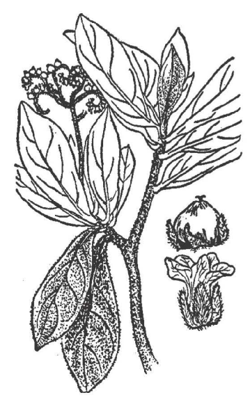

**Figure 5.5:** *Tournefortia argentea*.

Reconstructing the PPn form from the cognate set below is tricky. There are two competing PNPn reconstructions, *tausinu and *tausunu: the latter almost certainly reflects the former with vowel assimilation. The Tongan, Niuean and Samoan forms reflect *tausuni, but for two reasons I prefer to reconstruct PPn *tausinu. First, it is favoured by the distribution of the data, as it is reflected in Nuclear Polynesian Pukapukan and in several Eastern Polynesian languages, whereas *tausuni reflects metathesis, then probable diffusion in the Tonga-Samoa area (A. Pawley, pers. comm.). Second, it is likely that the term was originally bimorphemic, and the second morpheme perhaps reflects PCP *sinu ‘a shrub or tree, possibly *Phaleria* sp.’ (§6.1.5). Both *Tournefortia argentea* and *Phaleria coccinea* have white flowers.

| **PPn** |  | *tausinu | ‘*Tournefortia argentea*’ (POLLEX) |
| --- | --- | --- | --- |
| Pn | Tongan | *touhuni* | ‘*Tournefortia argentea*’ |
| Pn | Niuean | *toihuni* | ‘*Tournefortia argentea*’ |
| Pn | Niuean | *taihuni* | ‘coastall growth, scrub’ |
| Pn | Samoan | *tausuni* | ‘*Tournefortia argentea*’ |
| **PNPn** |  | *tausinu | ‘*Tournefortia argentea*’ |
| Pn | Pukapukan | *taeyinu* | ‘*Tournefortia argentea*’ |
| Pn | Rapanui | *tainu* | ‘*Tournefortia argentea*’ |
| Pn | Rarotongan | *tauhinu* | ‘*Tournefortia argentea*’ |
| Pn | Tahitian | *tahinu* | ‘*Tournefortia argentea*’ |
| Pn | Māori | *tauhinu* | ‘shrub sp., *Pomaderris phylicifolia*’ |
| **PNPn** |  | *tausunu | ‘*Tournefortia argentea*’ |
| Pn | Anutan | *tauunu* | ‘*Tournefortia argentea*’ |
| Pn | East Uvean | *tauhunu* | ‘*Scaevola taccada*’ |
| Pn | Rennellese | *tausunu* | ‘*Tournefortia argentea*’ |
| Pn | Samoan | *tausunu* | ‘*Tournefortia argentea*’ |
| Pn | Tuvalu | *tauhunu* | ‘*Tournefortia argentea*’ |
| Pn | Tokelauan | *tauhunu* | ‘*Tournefortia argentea*’ |
| Pn | Sikaiana | *taunusu* | ‘tree sp.’ |
| Pn | Luangiua | *kausuŋu* | ‘a small tree’ |
| Pn | Manihiki | *tauhunu* | ‘a bush’ |
| Pn | Tongarevan | *tausunu* | ‘*Tournefortia argentea*’ |
| Pn | Tuamotuan | *toohonu* | ‘*Tournefortia argentea*’ |

The PMic form *cen ‘*Tournefortia argentea*’ looks at first sight as if it also reflects PROc *sinu. If it does, however, this is a result of borrowing, as PMic *c- reflects POc *d or *dr-, not POc *s-.

| **PMic** |  | *cen | ‘*Tournefortia argentea*’ |
| --- | --- | --- | --- |
| Mic | Kiribati | *ren* | ‘*Tournefortia argentea*’ |
| Mic | Marshallese | *(ki)ṛen* | ‘*Tournefortia argentea*’ |
| Mic | Chuukese | *c̣en* | ‘*Tournefortia argentea*’ |
| Mic | Woleaian | *c̣er* | ‘*Tournefortia argentea*’ |

#### 4.1.8. *Vitex trifolia* (syn. *Vitex negundo*) (Verbenaceae)

*Vitex trifolia* is an erect shrub or small tree: 1-5 m tall which grows on the beach and on muddy stream banks. In the older botanical literature it is sometimes confused with *Vitex rotundifolia*, a low-lying shrub less that a metre in height, growing inland on poor sandy soils (W. McClatchey, pers. comm.), and the two evidently form a taxon in Wayan Fijian: *drala ni mataðawa* ‘beach drala’ but *drala kaka* ‘wild drala’.

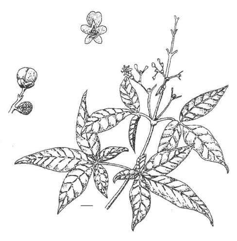

**Figure 5.6:** *Vitex trifolia*.

*Vitex trifolia* has sprays of blue-purple flowers and fruit. All parts of the plant are aromatic. On New Ireland the crushed leaves are used against headache. On Waya juice from the leaves is used as a healing agent for wounds (Peekel 1984:481, Gardner & Pawley 2006).

The POc term for *Vitex trifolia* was *drala. Both POc *drala ‘*Vitex trifolia*’ and POc *rarap ‘Indian coral tree, *Erythrina variegata*’ (§5.5) are regularly reflected as Bauan Fijian *drala*.[^13]: The two terms are disambiguated by the addition of *sala* ‘path, road, track’ to form the binomial *drala sala* ‘*Vitex trifolia*’.

In PPn the two forms would similarly have fallen together as *lala, but here the form survived with the meaning ‘*Vitex trifolia*’, whilst PPn †*lala ‘*Erythrina variegata*’ was lost.[^14]:

| **POc** |  | *drala | ‘shrub sp., *Vitex trifolia*’ |
| --- | --- | --- | --- |
| MM | Patpatar | *dala* | ‘*Vitex trifolia*’ |
| MM | Tolai | *dala* | ‘*Vitex trifolia*’ |
| NCal | Nyelâyu | *dāde* | ‘*Vitex trifolia*’ |
| Fij | Bauan | *drala (sala)* | ‘*Vitex trifolia*’ |
| Fij | Wayan | *drala* | ‘*Vitex trifolia*’ |
| **PPn** |  | *lala | ‘shrub, probably *Vitex* sp.’ |
| Pn | Tongan | *lala* | ‘taxon of shrubs inc. *Vitex trifolia*, *Dendrolobium umbellatum* and *Wikstroemia foetida*’ |
| Pn | Tongan | *lala(tahi)* | ‘*Vitex trifolia*’ (Whistler 1991b: 63) |
| Pn | Niuean | *lala* | ‘shrub sp., *Grewia crenata*’ |
| Pn | Niuean | *lala-tea* | ‘*Vitex trifolia*’ |
| Pn | East Uvean | *lala* | ‘shrub sp.’ |
| Pn | East Futunan | *lala(a-vao)* | ‘tree sp., *Myristica inutilis*’ |
| Pn | Anutan | *rara* | ‘*Vitex trifolia*’ |
| Pn | Tikopia | *rara* | ‘*Vitex trifolia*’ |
| Pn | Samoan | *lala* | ‘shrub, *Dendrolobium umbellatum*’ |
| Pn | Luangiua | *lala* | ‘shrub with fragrant flowers’ |
| Pn | Rarotongan | *rara* | ‘*Vitex trifolia*’ |

### 4.2. Climbers

#### 4.2.1. *Flagellaria indica*, supplejack, B *navula* (Flagellariaceae)

*Flagellaria indica* is a climbing cane-like vine whose stem, 1-1.5cm thick, grows to a length of 3-6 m. The leaves are 20-40cm long and have a curling tendril at the apex with which the plant secures itself to its host.

The long strong woody stem remains pliable and serves the functions of a rope. The stems are prepared for use as cordage by splitting them and drying them in the sun. They serve as a binding and plaiting material, especially to sew sago matting (Sorensen 1950, Peekel 1984: 76). They are also used as anchor cables and as rope: for bindings in canoe- and house construction and in roofing (Floyd 1954, S. Foale 2001, Thieberger 2006b). In various parts of the Solomons lengths of whole *Flagellaria indica* complete with their long leaves are joined together to make scarelines (Marovo *arara*, a reduplicated form of *ara* ‘*Flagellaria indica*’ ). These are laid out to encircle fish on reef flats or in the lagoon and scare them into traps or into an area of shallow water with a limited exit (Henderson & Hancock 1988:216, Hviding 2005: 101). On Lihir a potion made from *Flagellaria indica* is said to impart the ability to fight well (S. Foale 2001).

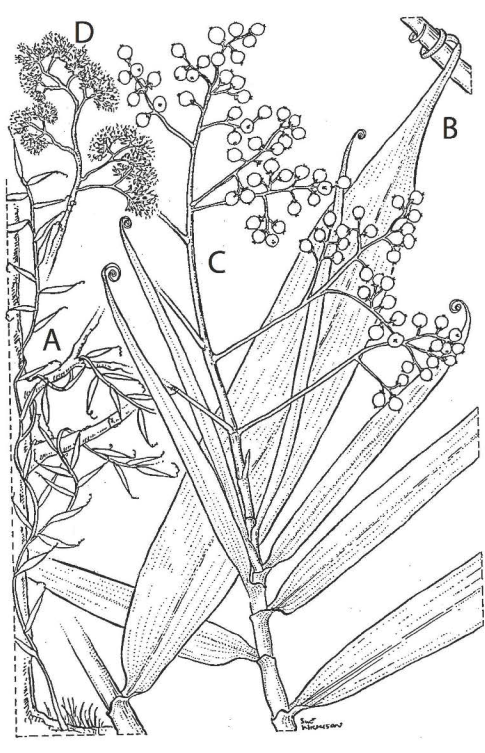

**Figure 5.7:** *Flagellaria indica*: **A**, climbing plant; **B**, leaf with tendrils; **C**; shoot with fruit; **D**, flowers.

POc *waR[e] ‘*Flagellaria indica*’ reflects PMP *huaR ‘*Flagellaria indica*’ (ACD). The expected POc descendant of this form is *waR, and this is reflected by Nduke *[a]r-ara* (reduplicated) and Kokota *n-ara*.[^15]: POc was seemingly resistant to monosyllabic content words, and Mussau, Seimat and Kwara’ae reflect a form with a final vowel, which shows up as *-e in Mussau and Kwara’ae.

The Muyuw, Sursurunga, Tangga and Mwotlap forms all reflect POc *-l-. Muyuw *weled* also has a final *-d*, and may be a chance resemblance rather than a cognate. The other forms shown under ‘cf. also’, however, are either outcomes of borrowing or reflect a POc alternant *wale.

| **PMP** |  | *huaR | ‘*Flagellaria indica*’ (ACD) |
| --- | --- | --- | --- |
| **POc** |  | *waR[e] | ‘*Flagellaria indica*’ |
| Adm | Mussau | *(ta)wale* | ‘liana sp.’ (Nevermann 1934) |
| Adm | Seimat | *wah* | ‘*Flagellaria indica*’ (Sorensen 1950) |
| MM | Varisi | *zara* | ‘*Flagellaria indica*’ (W. McClatchey, pers. comm.) |
| MM | Avasö | *zara* | ‘*Flagellaria indica*’ (W. McClatchey, pers. comm.) |
| MM | Nduke | *[a]r-ara* | ‘*Flagellaria indica*’ |
| MM | Marovo | *ara* | ‘*Flagellaria indica*’ |
| MM | Marovo | *ar-ara* | ‘long scare-lines of *Flagellaria indica* prepared for fishing’ |
| MM | Kokota | *n-ara* | ‘a tree creeper; rope made from the eponymous plant’ |
| MM | Maringe | *ñ-ara* | ‘*Flagellaria indica*’ (W. McClatchey, pers. comm.) |
| SES | Kwara’ae | *kʷale-kʷale* | ‘*Flagellaria indica*’ |
| SES | Kwara’ae | *ware-ware* | ‘*Flagellaria indica*’ (Henderson and Hancock 1988) |
| SES | Ulawa | *wale* | ‘*Flagellaria gigantea*’ (W. McClatchey, pers. comm.) |
| Fij | Wayan | *wā-wā* | ‘vine sp., *Ipomoea* indica; a shrubby climbing plant, *Ventilago vitiensis*’ |

cf. also:

| PT | Muyuw | *weled* | ‘*Flagellaria* sp.’ |
| --- | --- | --- | --- |
| MM | Lihir | *yal-yal* | ‘*Flagellaria indica*’ |
| MM | Sursurunga | *wal-wal* | ‘tree or bush type; cane type’ |
| MM | Tangga | *wāl-wāl* | ‘vine used in catching fish’(Bell 1946: 317) |
| NCV | Mwotlap | *(ɣa)wol* | ‘*Flagellaria* sp.’ |
| NCV | South Efate | *n-ala* | ‘*Flagellaria* sp.’ |

#### 4.2.2. *Hoya* spp. (Asclepiadaceae)

Leafy climbers of *Hoya* species are often found on the beach and around mangroves and beach trees (Peekel 1984: 455-457).

The reconstructions of PCEMP *(d,r)a(d,r)ap and POc *dradrap below are based on just two etyma, Muyuw *dadav* and Ngadha (CMP) *rara* ‘*Hoya* spp.’ (Verheijen 1990: 220).

| **PCEMP** |  | *(d,r)a(d,r)ap | ‘*Hoya* sp.’ |
| --- | --- | --- | --- |
| **POc** |  | *dradrap | ‘*Hoya* sp.’ |
| PT | Muyuw | *dadav* | ‘*Hoya* sp.’ (Damon 2004) |

## 5. Littoral forest

### 5.1. *Adenanthera pavonina* (syn. *Adenanthera gersenii*, *Adenanthera polita*, *Corallaria parvifolia*), bead tree, red sandalwood, B *bisa*, *nabisa* (Mimosaceae)

A tree which grows to 8-15 m on sandy foreshores and coral soil, *Adenanthera pavonina* is well known for its shiny scarlet, disk-shaped seeds about 6 mm in diameter which serve widely as necklace beads. It has a small, yellowish flower which grows in dense drooping rat’s-tail flower heads resembling catkins. Its flowers are white to yellowish, and the seeds grow in curved hanging pods, with a bulge opposite each seed, which curl up and turn brown (Peekel 1984: 210).

The wood is medium hard and in Vanuatu is used for houseposts (Gowers 1976: 19). French (1986: 75) reports that the leaves are eaten in some Papua New Guinea locations, but Peekel makes no mention of this.

| NCV | Namakir | *na-mara* | ‘*Adenanthera pavonina*’(Wheatley 1992: 133) |
| --- | --- | --- | --- |
| NCV | South Efate | *na-mara* | ‘*Adenanthera pavonina*’(Wheatley 1992: 133) |
| Fij | Bauan | *mala* | ‘*Dysoxylum lenticillare*, tree with large yellow-green flowers’ |
| Fij | Bauan | *mala-mala* | ‘*Dysoxylum* spp.’(Keppel et al. 2005) |
| Pn | Tongan | *mala-mala(-ʔa-toa)* | ‘small tree sp., *Memecylon harveyi*’(Whistler 1991b: 81) |
| Pn | Niuean | *ma-mala* | ‘k.o. tree’ |
| Pn | Emae | *mara-marā* | ‘*Adenanthera pavonina*’ |
| Pn | Ifira-Mele | *mʷara* | ‘*Adenanthera pavonina*’ (probably borrowed from a NCV language) |
| Pn | Tahitian | *mara* | ‘k.o. tree, *Nauclea forsteri*’ |
| Pn | Tuamotuan | *mara* | ‘k.o. tree, *Cordia subcordata*’ |

The data below allow the reconstruction of PSOc *bisu ‘bead tree, *Adenanthera pavonina*’ but may actually reflect a Pacific Pidgin term based on English ‘peas’ or ‘beads’.[^16]:

| NCV | Ambae | *bise* | ‘*Adenanthera pavonina*’ |
| --- | --- | --- | --- |
| NCV | Araki | *(vi)pisu* | ‘bead tree’ |
| NCV | Tangoa | *(vi)pisu* | ‘*Adenanthera pavonina*’ |
| NCV | Raga | *bisa* | ‘*Adenanthera pavonina*’ |
| NCV | Paamese | *vise* | ‘*Adenanthera pavonina*’ |
| NCV | Lewo | *(puru)piu* | ‘*Adenanthera pavonina*’ |
| SV | Sye | *ne-mpes* | ‘bead’ (ecclesiastical use only) |

### 5.2. *Barringtonia asiatica* (syn. *Barringtonia speciosa*, *Barringtonia littorea*), sea poison tree, fish poison tree, P *poesentri*, B *fisposentri* (Lecythidaceae)

For naming purposes, *Barringtonia* species in NW Island Melanesia fall into two groups:

- those with edible nuts: *Barringtonia novae-hiberniae*, *Barringtonia procera* and *Barringtonia edulis* (ch.11, §2.3); and
- those with inedible nuts, of which just one species, *Barringtonia asiatica*, has a reconstructable name and is the subject of this section.

Two other species with inedible nuts, *Barringtonia racemosa* and *Barringtonia niedenzuana*, resemble *Barringtonia edulis* in appearance.[^17]: The Patpatar and Tolai names for *Barringtonia racemosa* are respectively *paua-paua* and *pao-pao*, reduplicated forms of Patpatar *paua* and Tolai *pao* ‘*Barringtonia edulis*’ (Peekel 1984: 397-399), the reduplication expressing the inferiority of *Barringtonia racemosa* (ch.2, §7.2).

*Barringtonia asiatica* is a large beach tree, 10–20 m high, which is able to grow with its roots in salt water at times. It has large white and pink flowers which open at night and close in the morning, and ten-centimetre square fruits that float in the sea and sprout when they reach the shore. Fishermen use them as buoys or fishing floats. The seeds contain a poison. In New Ireland they are grated and thrown into the water to stun fish in pools on the reef. At Marovo they are sometimes used to kill dogs, but they also serve as medication for ringworm, scabies and other skin diseases (French-Wright 1983: 157, Peekel 1984: 397, Hviding 2005: 139)

Two terms are reconstructable, POc *putun, which is reflected all over Oceania except in parts of Vanuatu, where it is replaced by PNCV *vuabu,[^18]: and in the Chuukic languages of Micronesia, where it is replaced by a reflex of POc *kuluR ‘breadfruit, *Artocarpus altilis*’ (Ch.9, §4).

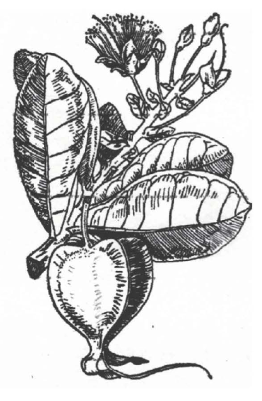

**Figure 5.8:** *Barringtonia asiatica*.

| **PMP** |  | *butun | ‘a shore tree, *Barringtonia*’ (Dempwolff 1938) |
| --- | --- | --- | --- |
| **POc** |  | *putun | ‘*Barringtonia asiatica*’ (Biggs 1965: *putu; French-Wright 1983) |
| Adm | Seimat | *hut* | ‘*Barringtonia asiatica*’ (Sorensen 1950) |
| Adm | Drehet | *puk* | ‘type of tree with poisonous seed used to kill fish’ |
| Adm | Loniu | *put* | ‘tree sp. and its fruit, used for stunning fish’ |
| NNG | Malai | *putin* | ‘*Barringtonia asiatica*’ |
| NNG | Sio | *puto* | ‘*Barringtonia asiatica*’ |
| NNG | Malasanga | *put-put* | ‘*Barringtonia asiatica*’ |
| NNG | Bing | *fut* | ‘*Barringtonia asiatica*’ |
| NNG | Manam | *utu* | ‘*Barringtonia asiatica*’ |
| PT | Muyuw | *uta-wut* | ‘*Barringtonia asiatica*’ (F. Damon, pers. comm.) |
| PT | Misima | *uta-utan* | ‘*Barringtonia asiatica*’ |
| MM | Vitu | *putu* | ‘*Barringtonia asiatica*’ |
| MM | Bola | *putu* | ‘*Barringtonia asiatica*’ |
| MM | Nakanai | *putu* | ‘*Barringtonia asiatica*’ |
| MM | Tigak | *utun* | ‘small tree sp. that grows on the beach’ |
| MM | East Kara | *futun* | ‘*Barringtonia asiatica*’ |
| MM | Lihir | *hut* | ‘*Barringtonia asiatica*’ |
| MM | Tangga | *fut* | ‘fish poison from seed of *Barringtonia asiatica*’ |
| MM | Patpatar | *hutun* | ‘*Barringtonia asiatica*’ |
| MM | Tolai | *vutun* | ‘*Barringtonia asiatica*’ |
| MM | Halia | *(ha)putun* | ‘*Barringtonia asiatica*’ |
| MM | Teop | *posus* | ‘*Barringtonia asiatica*’ |
| MM | Mono-Alu | *puputu* | ‘*Barringtonia asiatica*’ (W. McClatchey, pers. comm.) |
| MM | Babatana | *pututu* | ‘*Barringtonia asiatica*’ |
| MM | Nduke | *pututu* | ‘*Barringtonia asiatica*’ |
| MM | Kokota | *putu* | ‘*Barringtonia asiatica*’ |
| **PEOc** |  | *putu(n) | ‘*Barringtonia asiatica*’ |
| SES | Gela | *vutu* | ‘*Barringtonia asiatica*’ |
| SES | Lau | *fū* | ‘*Barringtonia asiatica*’ |
| SES | Sa’a | *hū* | ‘*Barringtonia speciosa*’ |
| SES | Arosi | *hū* | ‘*Barringtonia speciosa*’ |
| NCV | Mota | *vutu* | ‘*Barringtonia speciosa*’ |
| NCV | Vera’a | *vur* | ‘*Barringtonia asiatica*’ |
| NCV | Ambae | *(vele) vutu* | ‘*Barringtonia asiatica*’ (*vele* ‘*Barringtonia edulis*’) |
| NCV | Raga | *vutu* | ‘*Barringtonia asiatica*’ |
| NCV | Lewo | *puru(wap)* | ‘*Barringtonia asiatica*’ |
| NCV | Lewo | *puru(kurki)* | ‘bush nut tree (its skin is used as fish poison): *Barringtonia edulis*’ |
| SV | Sye | *no-vont* | ‘*Barringtonia asiatica*’ |
| SV | Kwamera | *nə-kʷərəŋ* | ‘*Barringtonia asiatica*’ |
| NCal | Pije | *(ce)piuk* | ‘*Barringtonia asiatica*’ |
| NCal | Nyelâyu | *piyu* | ‘*Barringtonia asiatica*’ |
| NCal | Nêlêmwa | *(haele)wot* | ‘*Barringtonia asiatica*’ |
| Mic | Ponapean | *wī* | ‘*Barringtonia asiatica*’ |
| Mic | Mokilese | *wi* | ‘*Barringtonia asiatica*’ |
| Fij | Bauan | *vutu* | ‘*Barringtonia* sp.’ |
| Fij | Wayan | *vutu* | ‘*Barringtonia asiatica*’ |
| Pn | Tongan | *futu* | ‘*Barringtonia asiatica*’ |
| Pn | East Futunan | *futu* | ‘*Barringtonia asiatica*’ |
| Pn | Tikopia | *futu* | ‘*Barringtonia asiatica*’ |
| Pn | Samoan | *futu* | ‘*Barringtonia asiatica*’ |
| Pn | Marquesan | *hutu* | ‘*Barringtonia asiatica*’ |

| **PNCV** |  | *vuabu | ‘*Barringtonia asiatica*’ (Clark 1996) |
| --- | --- | --- | --- |
| NCV | Nokuku | *a-up* | ‘*Barringtonia asiatica*’ |
| NCV | Kiai | *uapo* | ‘*Barringtonia asiatica*’ |
| NCV | Araki | *(vi)apu* | ‘*Barringtonia asiatica*’ |
| NCV | Tamambo | *(vu)abu* | ‘*Barringtonia asiatica*’ |
| NCV | Sakao | *n-uap* | ‘*Barringtonia asiatica*’ |
| NCV | Uripiv | *n-uwaʙ* | ‘*Barringtonia asiatica*’ |
| NCV | Port Sandwich | *n-iaᵐb* | ‘*Barringtonia asiatica*’ |
| NCV | Paamese | *hoavu* | ‘*Barringtonia asiatica*’ |
| NCV | Lewo | *(puru)wapu* | ‘*Barringtonia asiatica*’ |
| NCV | Namakir | *n-oamʷ* | ‘*Barringtonia asiatica*’ |
| NCV | Nguna | *n-oapu* | ‘*Barringtonia asiatica*’ |

### 5.3. *Calophyllum inophyllum*, portia, Indian laurel, Alexandrian laurel, beach mahogany, TP *kalopilum*, B *tamanu*, *nabakura* (Clusiaceae)

Often with a short gnarled trunk or branches leaning out over the sea, *Calophyllum inophyllum* is a salient shore tree about 10–20 metres tall with fragrant flowers and small round fruit (Hviding 2005: 106).

Its red wood is very hard and difficult to work when it is seasoned. The grain is interlocked, and so the wood does not split easily (Margetts 2005b). Its straight smaller branches are used for pig spears, for outrigger booms and for building (Sorensen 1950, Floyd 1954, Peekel 1984: 377, Gardner & Pawley 2006). In Vanuatu the sap serves for patching holes in wood. In other parts of the Pacific the gum, bark, leaves, roots, flowers and oil from the seeds are used in traditional medicine (Gowers 1976:40, Gardner & Pawley 2006). Its macerated leaves are used to stupefy octopus in holes in the reef and its burnt fruit provide black hair dye. In the Ninigos, where Seimat is spoken, a brown dye is made from the yellowish milky sap (Record 1945, Sorensen 1950).

Other species of *Calophyllum* grow inland, hence straight, and provide even better timber than *Calophyllum inophyllum*, including canoe hulls. *Calophyllum kajewskii* (syn. *Calophyllum peekelii*) is a rain forest tree than grows up to 50 m.

There are a number of reconstructions with *Calophyllum* species as denotata. The most widely reflected is POc *pitaquR, inherited from PMP, and it is reasonably clear that it denoted ‘*Calophyllum inophyllum*’. The only evidence we have for the POc retention of PMP *-R is found in the reflexes in New Georgia languages: Nduke *vizolo*, Roviana *vi-vizolo* and Marovo *vi-vijolo*. However, the expected form in these languages is †*vita(ɣ)uru*, and the actual forms must be outcomes of borrowing. The languages of the western Solomons have complex and ill understood borrowing histories (Ross 2010b).

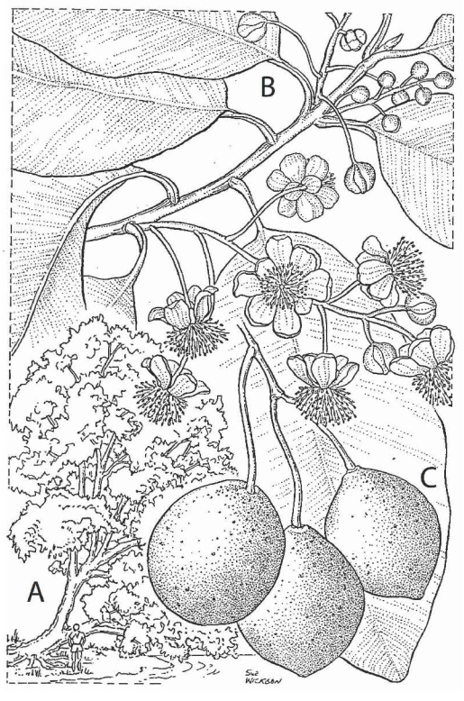

**Figure 5.9:** *Calophyllum inophyllum*: **A**, mature tree; **B**, flowering shoot; **C**, fruit cluster.

Other reconstructions glossed ‘*Calophyllum inophyllum*’ are PMM *bu(y)ap (possibly of POc antiquity) and POc *dalo (probably inherited from PCEMP). It seems unlikely that POc had more than one term for *Calophyllum inophyllum* and thus it is possible that *dalo denoted some other species. POc *tamanu and PNGOc *sabʷa(r,R)i denote unidentified *Calophyllum* species, whilst PEOc *bakuRa probably denoted *Calophyllum kajewskii*.

| **PMP** |  | *bitaquR | ‘*Calophyllum inophyllum*’ (ACD) |
| --- | --- | --- | --- |
| **POc** |  | *pitaquR | ‘*Calophyllum inophyllum*’ (Blust 1984: *Calophyllum* sp.) |
| Adm | Mussau | *[ŋ]itau* | ‘*Calophyllum*, coastal variety, tree from which slitgong is made’ |
| Adm | Lou | *pito* | ‘*Calophyllum inophyllum*’ |
| Adm | Seimat | *hita* | ‘*Calophyllum inophyllum*’ |
| Adm | Loniu | *pitow* | ‘*Calophyllum inophyllum*’ |
| Adm | Nauna | *pitɨʔ* | ‘*Calophyllum inophyllum*’ |
| Adm | Aua | *piʔaw* | ‘*Calophyllum inophyllum*’ |
| Adm | Titan | *pitow* | ‘tree sp.’ |
| MM | Meramera | *vitau* | ‘*Calophyllum*’ |
| MM | Teop | *vitawa* | ‘large tree, about 20m. tall, *Pentaspadon minutiflora* (Anacardiaceae)’ (Record 1945) |
| MM | Nduke | *vizolo* | ‘*Calophyllum vitiense*’ |
| MM | Roviana | *vi-vizolo* | ‘*Calophyllum vitiense*’ |
| MM | Marovo | *vi-vijolo* | ‘*Calophyllum vitiense*’ |
| **PROc** |  | *vitaquR | ‘*Calophyllum inophyllum*’ |
| SV | Sye | *na-viⁿru* | ‘*Meryta neoebudica*’ |
| SV | Anejom̃ | *na-hitau* | ‘tree sp.’ |
| NCal | Nyelâyu | *pʰic* | ‘*Calophyllum inophyllum*’ |
| NCal | Pije | *vʰic* | ‘*Calophyllum inophyllum*’ |
| NCal | Fwâi | *vʰic* | ‘*Calophyllum inophyllum*’ |
| NCal | Nemi | *fic* | ‘*Calophyllum inophyllum*’ |
| NCal | Jawe | *pʰic* | ‘*Calophyllum inophyllum*’ |
| NCal | Nyelâyu | *pʰic* | ‘*Calophyllum inophyllum*’ |
| NCal | Nêlêmwa | *fek* | ‘*Calophyllum inophyllum*’ |
| Mic | Kiribati | *itai* | ‘*Calophyllum inophyllum*’ |
| Mic | Kosraean | *itʌ* | ‘*Calophyllum inophyllum*’ |
| Mic | Mokilese | *icɔw* | ‘*Calophyllum inophyllum*’ |
| Mic | Ponapean | *isow* | ‘*Calophyllum inophyllum*’ |
| **PCP** |  | *vetaqu | ‘*Calophyllum inophyllum*’ |
| Fij | Bauan | *vetau* | ‘tree sp., *Mammea odorata* yielding a dye and a useful timber’ (ACD) |
| Fij | Wayan | *vetau* | ‘tree sp., probably *Mammea odorata*’ |
| Fij | Rotuman | *hefau* | ‘*Calophyllum inophyllum*’ |
| Pn | Tongan | *fetaʔu* | ‘*Calophyllum inophyllum*’ |
| Pn | Niuean | *fetau* | ‘*Calophyllum inophyllum*’ |
| Pn | East Futunan | *fetaʔu* | ‘tree sp., *Calophyllum* sp.’ |
| Pn | Emae | *fetau* | ‘*Calophyllum inophyllum*’ |
| Pn | Samoan | *fetau* | ‘*Calophyllum inophyllum*’ |
| Pn | Pukapukan | *wetau* | ‘large tree, excellent for making canoes’ |
| Pn | Rennellese | *hetaʔu* | ‘*Calophyllum inophyllum*’ |
| Pn | Tikopia | *fetau* | ‘*Calophyllum inophyllum*’ |

The cognate set below supports the reconstruction of PMM *bu(y)ap ‘*Calophyllum inophyllum*’. If the Tokelauan form is also cognate, then the form can be reconstructed to POc. Biggs & Clark (1993) attribute Tokelauan *pua* to the cognate set reflecting PPn *pua ‘*Fagraea berteroana* or other tree with showy flowers’ (which I take to reflect POc *buRat ‘*Fagraea berteroana*’; §5.6), but it may well be cognate with the Meso-Melanesian terms below.

| **PMM** |  | *bu(y)ap | ‘*Calophyllum inophyllum*’ |
| --- | --- | --- | --- |
| MM | East Kara | *vuəf* | ‘*Calophyllum inophyllum*’ |
| MM | Tabar | *buau* | ‘*Calophyllum inophyllum*’ |
| MM | Lihir | *boio* | ‘*Calophyllum inophyllum*’ |
| MM | Patpatar | *boiah* | ‘*Calophyllum inophyllum*’ |
| MM | Nehan | *beu* | ‘*Calophyllum inophyllum*’ |
| Pn | Tokelauan | *pua* | ‘*Calophyllum inophyllum*’ |

POc *tamanu evidently contrasted with *pitaquR ‘*Calophyllum inophyllum*’, and probably denoted one of the tall inland species listed above, as suggested by the Mussau gloss. The Fijian and Niuean reflexes denote *Calophyllum vitiense*, one of these inland species.

| **POc** |  | *tamanu | ‘*Calophyllum* sp.’ (ACD: *Calophyllum inophyllum*’) |
| --- | --- | --- | --- |
| Adm | Mussau | *tamanu* | ‘large-leafed *Calophyllum* sp. found in the interior’ (ACD) |
| Fij | Wayan | *damanu* | ‘*Calophyllum vitiense*’ |
| Fij | Bauan | *damanu* | ‘*Calophyllum vitiense*, very tall and straight, excellent for canoes’ |
| Pn | Niuean | *tamanu* | ‘an inland tree, *Calophyllum vitiense*’ |
| Pn | Tongan | *tamanu* | ‘*Calophyllum neoebudicum*’ (Whistler 1991b: 118-119) |
| Pn | East Futunan | *tamanu* | ‘tree sp., *Calophyllum* sp.’ |
| Pn | Samoan | *tamanu* | ‘*Calophyllum neoebudicum*’ (Whistler 2000: 201) |
| Pn | Tahitian | *tamanu* | ‘*Calophyllum inophyllum*’ |
| Pn | Hawaiian | *kamani* | ‘large tree, *Calophyllum inophyllum*’ |
| Pn | Tuamotuan | *tamanu* | ‘*Calophyllum inophyllum*’ |
| Pn | Rarotongan | *tamanu* | ‘the native: mahogany, *Calophyllum inophyllum*’ |

cf. also:

| SES | Kwara’ae | *kaumanu* | ‘*Calophyllum casiferum*’ |
| --- | --- | --- | --- |

Although a number of the reflexes below are glossed *Calophyllum inophyllum*, the Gela and Sa’a reflexes point to an inland species, probably *Calophyllum kajewskii*, as the gloss of PEOc *bakuRa.

| **PEOc** |  | *bakuRa | ‘*Calophyllum* sp., probably *Calophyllum kajewskii*’ (Geraghty 1990) |
| --- | --- | --- | --- |
| SES | Gela | *baɣula* | ‘large forest tree sp.’ |
| SES | Lau | *baule* | ‘*Calophyllum* sp.’ |
| SES | Kwaio | *baʔula* | ‘*Calophyllum kajewskii*’ |
| SES | Kwara’ae | *baʔula* | ‘*Calophyllum kajewskii*’ |
| SES | Sa’a | *paule* | ‘tree growing on the hills, makes good boat masts’ |
| SES | Arosi | *baʔura* | ‘tree sp.’ |
| NCV | Mwotlap | *b[ʋ]wʋy* | ‘*Calophyllum inophyllum*’ |
| NCV | Mota | *pawura* | ‘*Calophyllum inophyllum*’ |
| NCV | Ambae | *bagure* | ‘*Calophyllum* sp.’ |
| NCV | Araki | *(vi)tᫀaura* | ‘*Calophyllum inophyllum*’ |
| NCV | Raga | *baɣura* | ‘tree sp.’ |
| NCV | Uripiv | *bauɾ* | ‘*Calophyllum* sp.’ |
| NCV | Nese | *na-dᫀayro* | ‘*Calophyllum* sp.’ |
| NCV | Paamese | *voule* | ‘*Calophyllum* sp.’ |
| NCV | Lewo | *(puru)pala* | ‘*Calophyllum* sp.’ |
| NCV | Baki | *(buru)beulo* | ‘*Calophyllum* sp.’ |
| NCV | Namakir | *bakir* | ‘*Calophyllum* sp.’ |
| NCV | Nguna | *na-pakura* | ‘*Calophyllum* sp.’ |
| NCV | South Efate | *pakur* | ‘*Calophyllum* sp.’ |
| SV | Sye | *poɣur* | ‘*Calophyllum neoebudicum*’ |
| SV | Anejom̃ | *(n)peɣe* | ‘*Calophyllum inophyllum*’ |
| NCal | Pije | *pio* | ‘*Calophyllum inophyllum*’ |
| NCal | Jawe | *pio* | ‘*Calophyllum inophyllum*’ |
| NCal | Nêlêmwa | *fiiyo* | ‘*Calophyllum caledonicum*’ |
| NCal | Nyelâyu | *phio* | ‘*Calophyllum montanum*’ |

The forms reconstructed below also denoted a *Calophyllum* species.

PCEMP *talo is reconstructed on the basis of the data here and Ngadha (CMP) *talo* ‘*Calophyllum inophyllum*’ (Verheijen 1990). PCP *dilo below may well be a case of chance resemblance, as the *-i-* of the Central Pacific cognate set cannot be reconciled with the *-a-* of the cognate set supporting POc *dalo.

| **PCEMP** |  | *talo | ‘*Calophyllum inophyllum*’ |
| --- | --- | --- | --- |
| **POc** |  | *dalo | ‘*Calophyllum inophyllum*’ (Milh 1968) |
| PT | Muyuw | *dan* | ‘*Calophyllum streimannii*, *Calophyllum vexans*’ |
| SES | Gela | *dalo* | ‘shore tree sp.’ |
| SES | Sa’a | *dalo* | ‘*Calophyllum inophyllum*’ |
| SES | Kwara’ae | *dalo* | ‘*Calophyllum inophyllum*’ |
| SES | Lau | *dalo* | ‘*Calophyllum inophyllum*’ |
| Fij | Bauan | *dalo(voði)* | ‘*Hernandia olivacea*’ (Keppel et al. 2005) |

cf. also:

|  | PCP | *dilo | ‘*Calophyllum inophyllum*’ |
| --- | --- | --- | --- |
| Fij | Bauan | *dilo* | ‘*Calophyllum inophyllum*’ |
| Fij | Wayan | *dilo* | ‘*Calophyllum inophyllum*’ |
| Pn | East Futunan | *tilo* | ‘*Calophyllum inophyllum*’[^19] |
| Pn | Takuu | *tilo* | ‘crown of a tree’ |

| **PNGOc** |  | *sabʷa(r,R)i | ‘*Calophyllum* sp.’ |
| --- | --- | --- | --- |
| NNG | Takia | *sabor* | ‘*Calophyllum inophyllum*’ |
| NNG | Manam | *saboari* | ‘tree sp.’ |
| NNG | Kairiru | *sapar* | ‘*Calophyllum inophyllum*’ |
| PT | Muyuw | *apul* | ‘*Calophyllum peekelii*’ |

### 5.4. *Casuarina equisetifolia*, casuarina, beach she-oak, TP *yar*, B *aeantri*, *oktri* (Casuarinaceae)

*Casuarina equisetifolia* is a large coastal tree with an oddly feathery appearance caused by its needle-like leaves. Typically it grows to 20m, but Frederick Damon (pers.comm.) reports specimens on Woodlark Island of 40-45 m, towering above the rest of the forest. It yields heavy hard dark red-brown wood. The casuarina is used for building throughout most of NW Island Melanesia. In Kwara’ae country, clubs and axe handles are also made from it (Floyd 1954, Peekel 1984: 123, Kwa’ioloa & Burt 2001: 143, Whistler & Elevitch 2006b).

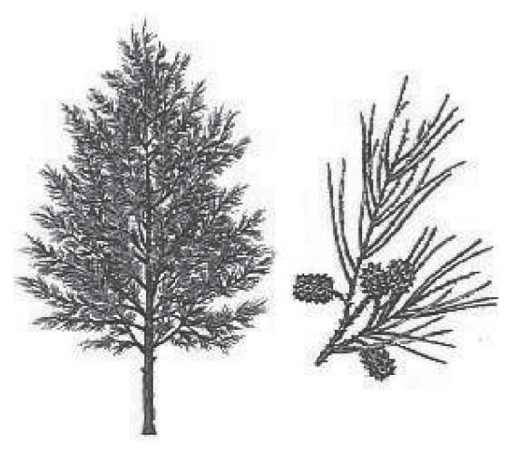

**Figure 5.10:** *Casuarina equisetifolia*.

The POc term for the casuarina was *aRu, but a compound form can also be reconstructed, namely POc *aRu-taŋis, consisting of *aRu plus *taŋis ‘weep’ - perhaps a metaphorical reference to the feathery and sometimes hanging foliage of the casuarina. However, I have no independent evidence of Oceanic speakers who make this connection.

The term for casuarina in Polynesian languages reflects PPn *toa, itself a reflex of POc *toRas ‘*Intsia bijuga*’ (ch.7, §4.9). This shift in denotatum presumably reflects the fact that both the casuarina and *Intsia bijuga* yield excellent hardwood.

So many reflexes of *aRu have an initial *y-* (or other accretion) that it is tempting to reconstruct †*yaRu. This would be an error, however. Frantisek Lichtenberk (1988) has shown the accretions in the SE Solomonic languages below are part of the regular reflexes of POc initial *a-. The same is evidently true in many other Oceanic languages, as accretions occur regularly in this context, as illustrated by a number of items reconstructed in volumes 1 and 2 for which non-Oceanic evidence requires the reconstruction of POc initial *a-.[^20]:

| **PMP** |  | *[q]aRuhu | ‘a shore tree: *Casuarina equisetifolia*’ (ACD) |
| --- | --- | --- | --- |
| **POc** |  | *aRu | ‘a shore tree, *Casuarina equisetifolia*’ (Blust 1972b) |
| Adm | Seimat | *yaŋ* | ‘*Casuarina equisetifolia*’ (Sorensen 1950) |
| NNG | Mengen | *lalu* | ‘*Casuarina equisetifolia*’ |
| NNG | Bariai | *eal* | ‘*Casuarina equisetifolia*’ |
| NNG | Gitua | *yaru* | ‘*Casuarina equisetifolia*’ |
| NNG | Tami | *yal* | ‘*Casuarina equisetifolia*’ |
| NNG | Sio | *yari-yari* | ‘*Casuarina equisetifolia*’ |
| NNG | Takia | *yar* | ‘*Casuarina equisetifolia*’ |
| PT | Muyuw | *yay* | ‘*Casuarina equisetifolia*’ |
| PT | Tawala | *(ke)yalu* | ‘*Casuarina equisetifolia*’ |
| PT | Saliba | *(kai)yalu* | ‘*Casuarina equisetifolia*’ |
| PT | Misima | *(e)yalu* | ‘*Casuarina equisetifolia*’ |
| MM | Vitu | *ɣeru* | ‘*Casuarina equisetifolia*’ |
| MM | Bulu | *aru* | ‘*Casuarina equisetifolia*’ |
| MM | Nakanai | *(le)alu* | ‘*Casuarina equisetifolia*’ |
| MM | Tolai | *iara* | ‘*Casuarina equisetifolia*’ |
| MM | Nehan | *ol-ol* | ‘*Casuarina equisetifolia*’ |
| MM | Solos | *yan* | ‘*Casuarina equisetifolia*’ |
| MM | Taiof | *(ar)ari* | ‘*Casuarina equisetifolia*’ |
| MM | Banoni | *dzaru* | ‘tree with dense hard red wood used for digging stick’ (P. Lincoln, pers. comm.) |
| MM | Babatana | *zaru* | ‘*Casuarina equisetifolia*’ |
| MM | Nduke | *(n)aru* | ‘*Casuarina equisetifolia*’[^21] |
| MM | Roviana | *(n)aru* | ‘*Casuarina equisetifolia*’ |
| MM | Marovo | *aru* | ‘*Casuarina equisetifolia*’ |
| MM | Kia | *n-aru* | ‘*Casuarina equisetifolia*’ (W. McClatchey, pers. comm.) |
| MM | Maringe | *ñ-aru* | ‘*Casuarina equisetifolia*’ (W. McClatchey, pers. comm.) |
| **PEOc** |  | *yaRu | ‘*Casuarina equisetifolia*’ (Geraghty 1990) |
| SES | Bugotu | *aru* | ‘*Casuarina equisetifolia*’ (W. McClatchey, pers. comm.) |
| SES | Lau | *salu* | ‘*Casuarina equisetifolia*’ |
| SES | Kwaio | *lalu* | ‘*Casuarina equisetifolia*’ |
| SES | Kwara’ae | *salu* | ‘*Casuarina equisetifolia*’ |
| SES | ’Are’are | *raru* | ‘*Casuarina equisetifolia*’ |
| SES | Sa’a | *salu* | ‘*Casuarina equisetifolia*’ |
| NCV | Mwotlap | *ey* | ‘*Casuarina equisetifolia*’ |
| NCV | Mota | *aru* | ‘*Casuarina equisetifolia*’ |
| NCV | Ambae | *aru* | ‘*Casuarina equisetifolia*’ |
| NCV | Araki | *(vi)aru* | ‘*Casuarina equisetifolia*’ |
| NCV | Tamambo | *(vu)aru* | ‘*Casuarina equisetifolia*’ |
| NCV | Uripiv | *n-uɾ* | ‘*Casuarina equisetifolia*’ |
| NCV | Neve’ei | *n-iar* | ‘*Casuarina equisetifolia*’ |
| NCV | Nese | *n-iar* | ‘*Casuarina equisetifolia*’ |
| NCV | Paamese | *e-ai* | ‘*Casuarina equisetifolia*’ |
| NCV | Lewo | *(puru)yalu* | ‘*Casuarina equisetifolia*’ |
| NCV | Namakir | *ne-ar* | ‘*Casuarina equisetifolia*’ |
| NCV | Nguna | *n-earu* | ‘*Casuarina equisetifolia*’ |
| NCV | South Efate | *n-ar* | ‘*Casuarina equisetifolia*’ |
| SV | Sye | *n-yar* | ‘*Casuarina equisetifolia*’ |
| SV | Lenakel | *n-iel* | ‘*Casuarina equisetifolia*’ |
| SV | Kwamera | *n-ier* | ‘*Casuarina equisetifolia*’ |
| SV | Anejom̃ | *n-ya* | ‘*Casuarina equisetifolia*’ |
| NCal | Jawe | *yōk* | ‘*Casuarina equisetifolia*’ |
| NCal | Nyelâyu | *n-aɣi* | ‘*Casuarina equisetifolia*’ |

| **POc** |  | *aRu-taŋis | ‘*Casuarina equisetifolia*’ |
| --- | --- | --- | --- |
| Adm | Mussau | *ataŋisi* | ‘*Casuarina equisetifolia*’ |
| MM | Lavongai | *aŋtaŋis* | ‘*Casuarina equisetifolia*’ |
| MM | East Kara | *iataŋis* | ‘*Casuarina equisetifolia*’ |
| MM | Tabar | *etaŋis* | ‘*Casuarina equisetifolia*’ |

The set below was gleaned from Guppy (1896), who gives Malagasy *jilau* and Fijian *velau*, both *Casuarina equisetifolia*’. To these may be added Ngaju Dayak *(kayu) walau* (Heyne 1950: 514). Although thin, the set allows the reconstruction of PMP/POc *pila(q)u.

| **PMP** |  | *pila(q)u | ‘*Casuarina equisetifolia*’ |
| --- | --- | --- | --- |
| **POc** |  | *pila(q)u | ‘*Casuarina equisetifolia*’ |
| Fij | Bauan | *velau* | ‘*Casuarina equisetifolia*’ |
| Fij | Wayan | *velau* | ‘*Casuarina equisetifolia*’ |

### 5.5. *Erythrina variegata* (syn. *Erythrina indica*), coral tree, Indian coral tree, TP *palpal*, B *narara* (Fabaceae)

Typically growing to 10-15 m, but sometimes to 20m, *Erythrina variegata* (Figure 5.11, left) occurs in two common forms. One has the variegated or yellowed leaves that have given rise to its name, as well as thorn-covered branches. The other form has green leaves and sometimes no thorns or just a few at the base of the trunk (Will McClatchey, pers. comm.). There are distinctive orange-red flowers in a spiral at the end of each branch. The bole is usually short and the trunk branches low with numerous ascending branches.

*Erythrina variegata* is typically found in sandy soil in littoral forest, but it is also often planted as an ornamental tree and as a support for the betel vine (Peekel 1984: 249, Wheatley 1992: 139-141, Whistler & Elevitch 2006c). Gowers (1976: 75) - but not Wheatley - says that in Vanuatu it is an introduced tree, but the NCV and SV reflexes of POc *rarap ‘*Erythrina* spp.’ speak against this. Indeed, Vanuatu is one of the locations where the flowering of *Erythrina variegata* is the marker of the yam-planting season (ch.9, §2.1).

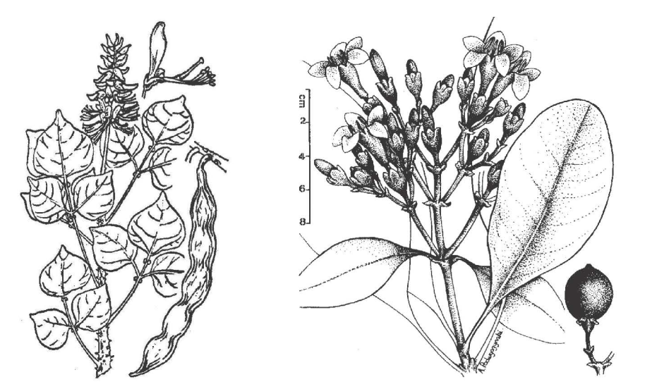

**Figure 5.11:** **Left** *Erythrina variegata*, Indian coral tree. **Right** *Fagraea berteroana*.

Among the Nakanai *Erythrina variegata* saplings are used to make pig spears and the leaves to dress wounds. It is widely used to make living fences (Floyd 1954, Arentz et al. 1989). Boiled in coconut milk the leaves make an excellent vegetable. Sorensen (1950) writes that they are eaten by immigrants to Ninigo but not by its natives.

POc appears to have had two terms denoting *Erythrina variegata*, *[baR]baR and *rarap, both inherited from PMP. Philippine cognates, however, suggest that PMP *baRbaR[^22]: denoted *Erythrina variegata* and *dapdap one or more other species, as Madulid (2001b: 121) lists Ilokano *bakbak* and Tagalog *bagbag* as ‘*Erythrina variegata*’ but Bagobo *dadap* and Hiligaynon Bisayan *dapdap* as ‘*Erythrina subumbrans*’ and Tagalog *dapdap* as ‘*Erythrina fusca*, *Erythrina subumbrans*’. *Erythrina fusca* is a swamp species and *Erythrina subumbrans* differs from other species in having flowers that are greenish to pale red (Whistler & Elevitch 2006c). It is thus likely that POc *rarap denoted a taxon of *Erythrina* spp. rather than just *Erythrina variegata*.

| **PMP** |  | *baRbaR | ‘coral tree, *Erythrina variegata*’ |
| --- | --- | --- | --- |
| **POc** |  | *[baR]baR | ‘coral tree, *Erythrina variegata*’ |
| NNG | Gitua | *bar(am)* | ‘*Erythrina variegata*’[^23] |
| NNG | Gedaged | *bal* | ‘*Erythrina variegata*’ |
| NNG | Takia | *bar* | ‘*Erythrina variegata*’ |
| NNG | Kairiru | *bar* | ‘*Erythrina variegata*’ |
| MM | East Kara | *vəl-vəl* | ‘*Erythrina variegata*’ |
| MM | Madak | *ban-ban* | ‘*Erythrina variegata*’ |
| MM | Patpatar | *bal-bal* | ‘*Erythrina variegata*’ |
| MM | Tolai | *bal-bal* | ‘*Erythrina variegata*’ |
| MM | Ramoaaina | *bal-bal* | ‘*Erythrina variegata*’ |
| Mic | Woleaian | *paẓ* | ‘*Erythrina variegata*’ |

As noted in §4.1.8, the expected reflex of POc *rarap ‘Indian coral tree, *Erythrina variegata*’ is PPn †*lala, but this was replaced by PPn *ŋatae, apparently because the PPn reflex of POc *drala ‘a shrub, *Vitex trifolia*’ was also *lala.

| **PMP** |  | *dapdap | ‘coral tree, *Erythrina* spp.’ (Dempwolff 1938) |
| --- | --- | --- | --- |
| **POc** |  | *rarap | ‘coral tree, *Erythrina* spp.’ (Blust 1972b *rara) |
| **PWOc** |  | *rap | ‘coral tree, *Erythrina* spp.’ (see text) |
| PT | Bwaidoga | *lalava* | ‘*Erythrina variegata*’ |
| PT | Wagawaga | *lalawa* | ‘*Erythrina variegata*’ (Holdsworth 1975a) |
| PT | Tawala | *lawa-lawa* | ‘tree type, large red flowers at end of July (probably *Erythrina variegata*)’ |
| MM | Sursurunga | *rara* | ‘tree type, fast-growing, looks like poplar’ |
| MM | Nehan | *rau-rau* | ‘*Erythrina* sp.’ |
| MM | Roviana | *rapo-rapo* | ‘*Erythrina* sp.’ |
| MM | Maringe | *grara* | ‘*Erythrina orientalis*’ (W. McClatchey, pers. comm.) |
| **PEOc** |  | *rarap | ‘Indian coral tree, *Erythrina variegata*’ |
| SES | Gela | *rara* | ‘*Erythrina* sp.’ |
| SES | Lau | *rara* | ‘*Erythrina fusca*’ |
| SES | Sa’a | *rara* | ‘*Erythrina variegata*’ |
| SES | Arosi | *rara* | ‘*Erythrina variegata*’ |
| NCV | Mwotlap | *yay* | ‘*Erythrina variegata*’ |
| NCV | Mota | *rara[v]* | ‘*Erythrina variegata*’ |
| NCV | Ambae | *rara* | ‘*Erythrina variegata*’ |
| NCV | Raga | *rara* | ‘*Erythrina variegata*’ |
| NCV | Araki | *(vi)ɾaɾa* | ‘*Erythrina variegata*’ |
| NCV | Tamambo | *(vu)rara* | ‘*Erythrina variegata*’ |
| NCV | Paamese | *a-rē* | ‘*Erythrina variegata*’ |
| NCV | Port Sandwich | *na-ⁿre* | ‘*Erythrina variegata*’ |
| NCV | Lewo | *(puru)tē* | ‘*Erythrina variegata*’ |
| **PSV** |  | *na-rap | ‘Indian coral tree, *Erythrina variegata*’ (Lynch 2001c) |
| SV | Sye | *na-rap* | ‘*Erythrina variegata*’ |
| SV | Lenakel | *na-iəv* | ‘flame tree’ |
| SV | Anejom̃ | *na-ra* | ‘*Erythrina variegata*’ |
| NCal | Pije | *dalep* | ‘*Erythrina variegata*’ |
| NCal | Nemi | *dalep* | ‘*Erythrina variegata*’ |
| NCal | Nyelâyu | *dālap* | ‘*Erythrina* sp.’ |
| Fij | Bauan | *drala* | ‘*Erythrina variegata*’ |
| Fij | Wayan | *rara* | ‘*Erythrina variegata*’ |

The forms Tawala *lawa-lawa* and Roviana *rapo-rapo* above suggest at first sight that the full reduplication of PMP *dapdap was exceptionally preserved in POc as †*raprap. Blust (1977a) has shown that in reduplicated forms, as elsewhere, POc normally lost the first member of a medial consonant sequence. Hence POc *rarap. Tawala and Roviana are both languages in which a vowel is added after a POc final consonant, and this vowel forms part of the reduplicand. The simplest interpretation is that *rarap was reduced to PWOc *rap, then reduplicated again to avoid the monosyllabicity which POc abhorred. The Roviana form in any case looks like a borrowing from an unknown source (the expected form is †*ra[va]rava).

### 5.6. *Fagraea berteroana* (syn. *Fagraea peekelii*) (Loganiaceae)

Of the three species of *Fagraea* that concern us here, one, *Fagraea berteroana*,[^24]: grows in the Bismarcks (Peekel 1984: 437) and is the principal denotatum of the reconstructions below (Figure 5.11, right). A second, *Fagraea racemosa* (syn. *Fagraea ligustrina*, *Fagraea maingayi*, *Fagraea pauciflora*) is not reported from the Bismarcks, although it is found on the New Guinea mainland and Bougainville and in the Solomons (Henderson & Hancock 1988: 171, Conn & Damas 2006). The third, *Fagraea gracilipes*, is reported only from the western Solomons and from Fiji (Hviding 2005: 104, Capell1941).

*Fagraea berteroana* takes several forms. Peekel describes two. In the Bismarcks it is either a foreshore shrub, 2-6 m tall, with no bole - it branches at ground level - or an epiphyte, growing on another tree, commonly *Inocarpus*, *Intsia* or *Calophyllum*, without a stem of its own and without taking nutrients from its host. The epiphyte form is also described by Kwa’ioloa & Burt (2001: 228) and mentioned by Wheatley (1992: 146) and Whistler & Elevitch (2006d). The latter two sources also describe a third form, a small tree growing to 15-20 m, with a bole that is rarely straight and often branches low. Frederick Damon (pers. comm.) reports that the bole is very durable and on Woodlark Island is sometimes used for houseposts instead of *Intsia bijuga*. In whatever form, *Fagraea berteroana* has wonderfully scented tubular white flowers which are white for the first two days, turning yolk-yellow on days 3 and 4. Its wood is light brown and durable.

*Fagraea racemosa* resembles the small-tree form of *Fagraea berteroana*, ranging from 2 to 10m in height, and occasionally reaching 16m. (Henderson & Hancock 1988: 171, Conn & Damas 2006). *Fagraea gracilipes* is a lowland forest tree that grows in swamps or mud (Hviding 2005: 104). It is effectively in complementary distribution with *Fagraea racemosa*, which abhors such habitats.

The three species are apparently used in much the same ways. The flowers serve as personal decoration. Posts cut from *Fagraea* shrubs are used to establish living fences. *Fagraea* poles are used in canoe and house construction at a number of locations, e.g. SE Papua New Guinea (Kinch 1999) and parts of the Solomons (Waterhouse 1949, Henderson & Hancock 1988: 171), because the branches grow straight and erect and, according to Hviding (2005: 102, 104, 110), the wood never rots and is resistant to white ants. Hviding and Capell report that *Fagraea gracilipes* is used for house posts at Marovo and in Fiji respectively, Wheatley (1992: 146, 148) that *Fagraea berteroana* is similarly used in Vanuatu, and especially on Aneityum.

In the light of these observations the etymon below may be identical with POc *bou, denoting the main bearers or central post of a house (vol.1, ch.3, §3.4). The Sye cognate apparently denotes two tree species, neither of them a *Fagraea* species, but both are used for house construction. It is also possible that *bou may be identical with *bau ‘hardwood taxon’ (ch. 7, §4.10), given that almost all the examples supporting the latter are from Central Pacific languages and may reflect a change of denotation in PCP.

| **POc** |  | *bou | ‘*Fagraea* spp.’ |
| --- | --- | --- | --- |
| NNG | Mangap | *bou* | ‘tree sp. used for building’ |
| MM | Teop | *bao* | ‘*Fagraea racemosa*’ |
| MM | Nduke | *bou* | ‘a forest tree that grows in swamps in muddy places, *Fagraea gracilipes*’ |
| MM | Roviana | *bou* | ‘tree with hard timber useful and impervious to white ants, perhaps *Guettarda* sp.’ |
| MM | Marovo | *bou* | ‘a swamp tree, *Fagraea gracilipes* (?), ant-resistant’ |
| MM | Kia | *bou* | ‘*Fagraea gracilipes*’ (W. McClatchey, pers. comm.) |
| MM | Gao | *bou* | ‘*Fagraea gracilipes*’ (W. McClatchey, pers. comm.) |
| SES | Ghari | *bou (kora)* | ‘*Fagraea racemosa*’ |
| SV | Sye | *na-mpou* | ‘*Dysoxylum gaudichaudianum*, *Alphitonia zizyphoides*’ |
| SV | Anejom̃ | *no-pou* | ‘*Fagraea berteroana*’ |

PPn *pou-muli ‘*Flueggea flexuosa*’ was apparently a compound reflecting POc *bou ‘*Fagraea* spp.’ as its first element and POc *muri[-] ‘back part, rear’ (vol.2, ch.8, §2.3.7) as its second. We assume the association in meaning was that the tree(s) denoted by reflexes of POc *bou and by PPn *pou-muli were all used in house-building. Milner (1966) notes that in Samoa the Flueggea species denoted by *pou-muli* provided timber ‘used for outrigger booms, house posts etc.’.

| **PPn** |  | *pou-muli | ‘*Flueggea flexuosa*’ |
| --- | --- | --- | --- |
| Pn | Tongan | *pou(muli)* | ‘*Flueggea flexuosa*’ |
| Pn | East Uvean | *pou(muli)* | ‘*Flueggea flexuosa*’ |
| Pn | Samoan | *pou(muli)* | ‘*Flueggea flexuosa*’ |

cf. also:

| Pn | East Futunan | *pou(tea)* | ‘tree sp., *Flueggea samoana*’ |
| --- | --- | --- | --- |

POc *buRat was apparently the specific term for *Fagraea berteroana*. Central Pacific reflexes quite often instead denote *Guettarda speciosa*, another plant with sweet-smelling flowers but a quite different appearance. Pawley & Sayaba (2003) gloss the Wayan reflex as denoting a taxon including various species that have pretty and sweet-scented flowers. If PCP *bua had such a range of meaning, then the application of its reflexes to *Guettarda* speciosa is readily explained. However, things were apparently more complicated than this, as a reduplicated PCP form *bua-bua is also reconstructable and it is not clear how this differed in meaning from *bua. PCEMP *buRat is perhaps also reconstructable in the light of a single putative cognate, Ende *bore* (Flores, CMP; Verheijen 1990: 213).

| **POc** |  | *buRat | ‘*Fagraea berteroana*’ |
| --- | --- | --- | --- |
| MM | Roviana | *bu-burata* | ‘*Fagraea berteroana*’ |
| MM | Marovo | *bu-burata* | ‘a woody climber of the elevated barrier reef’ |
| SES | Kwara’ae | *bula* | ‘*Fagraea berteroana*’ (Whitmore 1966: 138) |
| SES | Lau | *bule* | ‘*Plumeria acutifolia*’ |
| NCal | Jawe | *guec* | ‘*Fagraea schlechteri*’ |
| NCal | Nemi | *guec* | ‘*Fagraea schlechteri*’ |
| NCal | Nêlêmwa | *buak* | ‘*Fagraea schlechteri*’ |
| NCal | Xârâcùù | *buɛ* | ‘*Fagraea schlechteri*’ |
| Mic | Ponapean | *pʷur* | ‘*Fagraea berteroana*’ (Whistler and Elevitch 2006d) |
| Fij | Rotuman | *pua* | ‘*Plumeria acutifolia*’ |
| Fij | Wayan | *bua* | ‘taxon of trees with pretty, sweet-scented flowers: includes *Gardenia augusta*, *Plumeria rubra* and *Fagraea* spp.’ |
| Fij | Wayan | *bua (ni viti)* | ‘*Fagraea* spp.’ |
| Fij | Wayan | *bua(toka)* | ‘*Guettarda speciosa*’ |
| Fij | Bauan | *bua* | ‘*Fagraea* spp.’ |
| **PPn** |  | *pua | ‘taxon including *Fagraea berteroana* and *Guettarda speciosa*’ |
| Pn | Niuean | *pua* | ‘bud; tree sp, *Fagraea berteroana*’ |
| Pn | Tongan | *pua* | ‘*Fagraea berteroana*’ |
| Pn | East Uvean | *pua* | ‘*Fagraea berteroana*’ |
| Pn | East Futunan | *pua* | ‘*Fagraea berteroana*’ |
| Pn | Anutan | *pua* | ‘flower; plant with flowers (v.)’ |
| Pn | Tikopia | *pua* | ‘*Fagraea* sp.’ |
| Pn | Rennellese | *pua* | ‘tree with fragrant flowers’ |
| Pn | Rennellese | *pua (ʔatua)* | ‘*Fagraea berteroana*’ |
| Pn | Rennellese | *pua(bano)* | ‘*Guettarda speciosa*’ |
| Pn | Samoan | *pua* | ‘*Gardenia taitensis*’ (traditional usage; (Whistler 2000: 194)) |
| Pn | Tuvalu | *pua* | ‘*Guettarda speciosa*’ |
| Pn | Kapingamarangi | *pua* | ‘*Guettarda speciosa*’ |
| Pn | Kapingamarangi | *bua* | ‘*Fagraea berteroana* or other plant with showy flowers’ |
| Pn | Nukuria | *bua* | ‘*Guettarda speciosa*’ |
| Pn | Tongarevan | *pua* | ‘bloom (v.)’ |
| Pn | Rarotongan | *pua* | ‘*Fagraea berteroana*’ |
| Pn | Tahitian | *pua* | ‘*Allamanda cathartica*’ (R. Gardner, pers. comm.) |
| Pn | Tuamotuan | *pua* | ‘blossom, flower (v.)’ |

| **PCP** |  | *bua-bua | ‘*Guettarda speciosa* or *Fagraea* sp.’ |
| --- | --- | --- | --- |
| Fij | Bauan | *bua-bua* | ‘tree with very hard incorruptible wood, used for making the posts of houses, *Fagraea gracilipes*’ |
| **PPn** |  | *pua-pua | ‘*Guettarda speciosa*’ |
| Pn | Tongan | *puopua* | ‘*Guettarda speciosa*’ |
| Pn | West Uvea | *puapua* | ‘*Guettarda speciosa*’ |
| Pn | Pukapukan | *puapua* | ‘*Guettarda speciosa*’ |
| Pn | Samoan | *puapua* | ‘*Guettarda speciosa*’ |
| Pn | Tokelauan | *puapua* | ‘*Guettarda speciosa*’ |
| Pn | Māori | *puapua* | ‘a white-flowered climber, *Clematis paniculata*’ |

### 5.7. *Flueggea flexuosa* (syn. *Securinega flexuosa*), B *namemiwa*, *namamao* (Euphorbiaceae)

*Flueggea flexuosa* is a medium-sized tree of 10-15 m which grows on coral in coastal locations and also, in the Solomons, in lowland forests. Its natural range extends from the Philippines to northern Vanuatu, but it is absent from New Guinea and the Bismarcks (Thomson 2006b).

It provides moderately heavy hard straight wood which is slow to rot in contact with dry soil. It is considered to be among the best building timbers in the Solomons and so is used for posts and for house construction by the Nduke, as well as for pig fences. It is best for largescale construction, since it cracks as it dries, and for this reason is not used for carving (Kwa’ioloa & Burt 2001: 107, Hviding 2005: 129, Scales n.d.). At Marovo scrapings of the bark are an ingredient in many medicines.

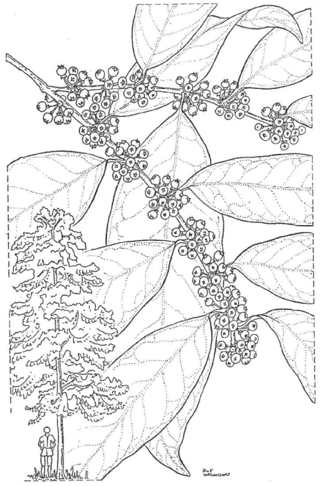

**Figure 5.12:** *Flueggea flexuosa*: tree and fruit-bearing shoot.

Although the Madak reflex refers to *Falcataria moluccana*, a tree vastly different in size (at 60 m the tallest in the forest), Kwa’ioloa & Burt (2001: 107) perceive its leaves to be similar to the leaves of *Flueggea flexuosa*.

The gloss of POc *mapuqan is marked as doubtful below because *Flueggea flexuosa* was apparently not present in the Bismarcks and thus perhaps unknown to POc speakers. However, this is problematic, as regular reflexes denote *Flueggea flexuosa* in NW Solomonic, SE Solomonic and North-Central Vanuatu languages, and the most recent interstage that these groups are commonly descended from is POc. (For Polynesian terms for *Flueggea flexuosa*, see §5.6.)

| **POc** |  | *mapuqan | ‘*Flueggea flexuosa*’ (?) |
| --- | --- | --- | --- |
| MM | Madak | *[vap]mavu* | ‘*Albizia falcataria*’ |
| MM | Mono-Alu | *ma-mahuana* | ‘*Flueggea flexuosa*’ (Thomson 2006b) |
| MM | Nduke | *mavuɣana* | ‘*Flueggea flexuosa*’ |
| MM | Roviana | *mavuana* | ‘*Flueggea flexuosa*’ |
| MM | Marovo | *mavuana* | ‘*Flueggea flexuosa*’ |
| MM | Kia | *mafuna* | ‘*Flueggea flexuosa*’ (W. McClatchey, pers. comm.) |
| SES | Bugotu | *mavua* | ‘*Flueggea flexuosa*’ (Henderson and Hancock 1988) |
| SES | Ghari | *mavua* | ‘*Flueggea flexuosa*’ |
| SES | Kwara’ae | *ma-mufua* | ‘*Flueggea flexuosa*’ (Henderson and Hancock 1988) |
| SES | Kwaio | *ma-mafua* | ‘*Flueggea flexuosa*’ (Henderson and Hancock 1988) |
| NCV | Mwotlap | *mo-mou* | ‘*Flueggea flexuosa*’ |
| NCV | Apma | *ma-mau* | ‘*Flueggea flexuosa*’ |
| NCV | Vera’a | *ma-mau* | ‘*Flueggea flexuosa*’ |
| NCV | Tamambo | *(vu)ma-mau* | ‘*Flueggea flexuosa*’ (Thomson 2006b) |

### 5.8. *Guettarda speciosa* (Rubiaceae)

*Guettarda speciosa* is a hardwood tree with a short bole that grows to a height of 3-12 m in a variety of coastal habitats. Hviding (2005: 151) reports that at Marovo it grows on the landward margin of the mangrove swamp and is tolerant of salt water. It is included here among littoral forest trees because Peekel (1984: 533) writes that in New Ireland it is ‘[c]ommon on the foreshore; as abundant on the cliffs as on the sand’. Wheatley (1992: 198) reports that it is infrequent in Vanuatu.

This tree has a number of uses: in the small islands of the Calvados chain (off the southeastern tip of the New Guinea mainland) it is used in house construction (Kinch 1999). At Marovo it is used for firewood and for making barkcloth mallets (Hviding 2005: 151).

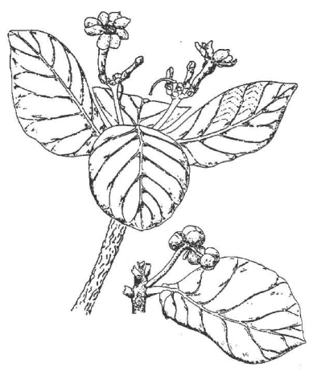

**Figure 5.13:** *Guettarda speciosa* .

*Guettarda speciosa* is sometimes labelled with the same term as the epiphyte *Fagraea berteroana*, apparently because both are sweet-smelling (§5.6), but the POc term for *Guettarda speciosa* was *pʷano or *pʷano-pʷano.

| **POc** |  | *[pʷano]pʷano | ‘*Guettarda speciosa*’[^25] |
| --- | --- | --- | --- |
| PT | Muyuw | *pano-pan* | ‘*Guettarda* sp.’ |
| NCV | Mwotlap | *pʷon-pʷon* | ‘*Guettarda speciosa*’ |
| NCV | South Efate | *n-fan* | ‘*Guettarda speciosa*’ |
| **PSV** |  | *na-(v,w)an(vu) | ‘*Guettarda speciosa*’ |
| SV | Sye | *uven-uven* | ‘*Guettarda speciosa*’ |
| SV | Lenakel | *n-uen* | ‘*Guettarda speciosa*’[^26] |
| SV | Anejom̃ | *na-vanhu* | ‘*Guettarda speciosa*’[^27] |
| NCal | Iaai | *φeñi* | ‘*Guettarda speciosa*’ |
| **PPn** |  | *(f,p)ano | ‘*Guettarda speciosa*’ |
| Pn | Niuean | *pano-pano* | ‘*Guettarda speciosa*’ |
| Pn | Marquesan | *hano* | ‘*Guettarda speciosa*’ |
| Pn | Rarotongan | *ano* | ‘*Guettarda speciosa*’ |
| Pn | Tahitian | *(tā)fano* | ‘*Guettarda speciosa*’ |

### 5.9. *Gyrocarpus americanus*, canoe tree, B *naove*, *kenutri* (Hernandiaceae)

Wheatley (1992: 114) comments that the canoe tree, *Gyrocarpus americanus*, is a key indicator of a region with a distinct dry season. It is confined to coastal strips and low coral plateaus which lie in a rain shadow during the drier season when the SE trades are prevalent. Because of its location and because its soft wood is easily worked, it is the tree from which dugout canoes are made in north and central Vanuatu - and this is its only use. It is used for the same purpose in New Ireland (Peekel 1984: 192). On Waya Island the soft wood was used to construct simple in-shore fishing rafts, and the bark was made into a tonic and medicine for high blood pressure (Gardner & Pawley 2006).

The canoe tree grows to a height of 30-40 m. It has a smooth grey-brown trunk, which can be huge (Peekel reports a specimen 8.25 m in diameter), and a sparse crown which loses its leaves in the dry season.

According to Peekel, the leaves and the flowers both smell unpleasant, the leaves like garlic, the flowers acrid, hence its name in Patpatar, *i-bore*, and Tolai, *i-boroi*, literally ‘pig tree’.

POc *qope appears to have been the term for *Gyrocarpus americanus*. Only one reliable reflex is outside NCV, namely Titan *ñow*. Titan *ñ-* reflects Proto Admiralty *n-q-, where *n- in turn reflects the POc article *na which in Admiralties languages often combines with the initial consonant of a noun (Ross 1988: 340–341). The phonological history of Drehet is not sufficiently well known to be sure whether Drehet *nip* also reflects *qope.

| **POc** |  | *qope | ‘*Gyrocarpus americanus*’ |
| --- | --- | --- | --- |
| Adm | Titan | *ñ-ow* | ‘tree sp. used for making canoes’ |
| **PNCV** |  | *(q)ove | ‘*Gyrocarpus americanus*’ (Clark 1996) |
| NCV | Mota | *ovi* | ‘tree sp .’ |
| NCV | Raga | *ove* | ‘*Gyrocarpus americanus*’ |
| NCV | Nokuku | *ova* | ‘canoe’ |
| NCV | Port Sandwich | *na-öv* | ‘*Gyrocarpus americanus*’ |
| NCV | Paamese | *uh-uh* | ‘*Gyrocarpus americanus*’ |
| NCV | Lewo | *(puru)iove* | ‘*Gyrocarpus americanus*’ |

cf. also:

| Adm | Drehet | *n-ip* | ‘softwood tree sp. used to make canoe hulls and house frames’ |
| --- | --- | --- | --- |

### 5.10. *Neisosperma oppositifolium* (syn. *Ochrosia oppositifolia*, *Ochrosia parviflora*), twin apple, B *tufrut* (Apocynaceae)

Perhaps because of a lack of relevant data, no POc term is reconstructable for *Neisosperma oppositifolium* although it occurs in the Bismarcks. A small tree restricted to the coastal edge of the littoral forest and growing to 5-8m, it has dense clusters of white flowers a centimetre in diameter at the ends of its branches and pairs of fruit which in shape and size resemble a betelnut with a pointed and slightly turned tip. Hence its Kwara’ae name *ai-kikiru* ‘betel tree’ (*kikiru* ’betelnut palm, *Areca catechu*). Internally the fruit is betelnut-like, too: it has a thick dry husk enclosing the nut which contains two seeds.

The tree provides good straight poles for the lighter parts of house construction, as well as being good firewood. The thick latex beneath the outer bark has medicinal uses (Peekel 1984:443-445, Wheatley 1992:48-50, Kwa’ioloa & Burt 2001: 124, Gardner & Pawley 2006).

At present no term is reconstructable at an interstage earlier than PROc *vaRo. Gedaged (NNG) *faɬoŋ* ‘tree sp., the trunk of which is used to make canoes’ looks cognate but reflects POc †*pa(r,R)oŋV, which has an extra syllable not reflected in the Remote Oceanic cognate set.

The PSOc form *vato, reconstructed by Lynch (2004a), seems to be an irregular reflex of PROc *vaRo.

| **PROc** |  | *vaRo | ‘*Neisosperma oppositifolium*’ |
| --- | --- | --- | --- |
| NCV | Mota | *varo-varo* | ‘*Neisosperma oppositifolium*’ |
| NCV | Vera’a | *var-var* | ‘*Neisosperma oppositifolium*’ |
| NCV | Araki | *ðᫀara-ðᫀara* | ‘*Neisosperma oppositifolium*’ |
| NCV | Raga | *varo-varo* | ‘*Neisosperma oppositifolium*’ (Walsh 2004) |
| NCV | Uripiv | *(bi)vaɾ-vaɾ* | ‘*Neisosperma oppositifolium*’ |
| Mic | Marshallese | *(kəc)pɯaṛɯ* | ‘*Neisosperma oppositifolium*’ |
| Fij | Rotuman | *hao-hao* | ‘tree with white flowers’ |
| Fij | Wayan | *vāō* | ‘*Neisosperma oppositifolium*’ |
| Fij | Bauan | *vāō* | ‘*Neisosperma oppositifolium*’ |
| Pn | Tongan | *fao* | ‘*Neisosperma oppositifolium*’ |
| Pn | East Uvean | *fao* | ‘tree sp.’ |
| Pn | Emae | *fao* | ‘*Neisosperma oppositifolium*’ |
| Pn | Samoan | *fao* | ‘*Neisosperma oppositifolium*’ |
| Pn | Tuvalu | *fao* | ‘*Neisosperma oppositifolium*’ |
| Mic | Kiribati | *pao* | ‘*Neisosperma oppositifolium*’ |

| **PSOc** |  | *vato | ‘*Neisosperma oppositifolium*’ (Lynch 2004a) |
| --- | --- | --- | --- |
| NCV | South Efate | *(n)fato* | ‘*Neisosperma oppositifolium*’ |
| SV | Sye | *(ye)vat* | ‘*Neisosperma oppositifolium*’ |

### 5.11. *Pisonia* spp. (syn. *Ceodes* spp.), B *nambuka*, *sofsofwud* (Nyctaginaceae)

Two species of *Pisonia* occur in the Bismarcks: *Pisonia umbellifera* (syn. *Pisonia excelsa*, *Pisonia brunoniana*) and *Pisonia grandis* (Figure 5.14, left). The main difference between them is their habitat. *Pisonia umbellifera* is common in secondary forest, whilst *Pisonia grandis* is confined to the littoral strip, just above the high-water mark. In Vanuatu it is occasionally cultivated in coastal villages.

Both are trees growing to 10-20m in height, with a bole which divides low into several erect branches. Both species have sweet-smelling white flowers. Their fruit are narrow (2-5 mm across) and cylindical (3cm long) and have a sticky exudate which attaches them to anything, including bird feathers. Their soft wood is useless, even as fuel, but the fruit were traditionally used in bird traps. The leaves of *Pisonia grandis* were consumed as a vegetable in Vanuatu (Wheatley 1992: 186–189).

| **PMP** |  | *anuliŋ | ‘*Pisonia umbellifera*’ (ACD) |
| --- | --- | --- | --- |
| **POc** |  | *[a]ñuliŋ | ‘*Pisonia* sp.’ (John Lynch, pers. comm.) |
| MM | Tolai | *nula* | ‘tree sp., fruit and young leaves of which are edible’ |
| MM | Maringe | *ñuli* | ‘*Pisonia grandis*’ (W. McClatchey, pers. comm.) |
| SES | Bugotu | *ñuli* | ‘*Pisonia grandis*’ (W. McClatchey, pers. comm.) |
| SES | Kwara’ae | *nuli* | ‘*Albizia salomonensis*’ |
| NCal | Nêlêmwa | *ôôli* | ‘*Pisonia grandis*’ |

| **PROc** |  | *buka | ‘taxon of littoral trees, including *Pisonia* spp. and *Gyrocarpus americanus*’ (Geraghty 1983 *puka ‘Hernandia pisonia’) |
| --- | --- | --- | --- |
| NCV | Ambae | *boɣa* | ‘*Pisonia umbellifera*’ |
| NCV | Nduindui | *na-mbuka* | ‘*Pisonia umbellifera*’ |
| NCV | Raga | *buɣo* | ‘*Pisonia umbellifera*’ |
| NCV | Namakir | *bik* | ‘*Pisonia* or *Hernandia* sp.’ |
| NCV | Nguna | *na-puka* | ‘*Gyrocarpus americanus*’ |
| NCV | South Efate | *na-puk* | ‘*Gyrocarpus americanus*’ |
| NCV | South Efate | *na-puk(-mokul)* | ‘*Pisonia umbellifera*’ |
| SV | Sye | *na-mpɣai* | ‘*Pisonia umbellifera*’ |
| NCal | Nyelâyu | *vic* | ‘*Pisonia aculeata*’ |
| Mic | Kiribati | *buka* | ‘*Pisonia grandis*’ |
| Mic | Ponapean | *puek* | ‘tulip tree sp.’ |
| **PCP** |  | *buka | ‘taxon of littoral trees, including *Pisonia* spp., *Hernandia nymphaeifolia* and *Gyrocarpus americanus*’ |
| Fij | Bauan | *buka(ni vuda)* | ‘*Guioa rhoifolia*’ |
| Fij | Rotuman | *puka* | ‘creepers of various kinds’ |
| Pn | Niuean | *puka* | ‘*Pisonia* sp.’ |
| Pn | Tongan | *puko* | ‘*Pisonia grandis*’ |
| Pn | Tongan | *puko (vili)* | ‘*Gyrocarpus americanus*’ (‘spinning *puko*’, so named because of aerodynamics of thrown fruit) (Whistler 1991b: 109) |
| Pn | Samoan | *puʔa (vai)* | ‘*Pisonia grandis*’ |
| Pn | East Uvean | *puko* | ‘*Hernandia nymphaeifolia*’ |
| Pn | East Futunan | *puka* | ‘*Pisonia* sp.’ |
| Pn | Pukapukan | *puka* | ‘*Pisonia umbellifera*’ |
| Pn | Rennellese | *puka* | ‘*Pisonia grandis*’ |
| Pn | Tikopia | *puka* | ‘*Hernandia nymphaeifolia*’ |
| Pn | West Futunan | *puka* | ‘a kind of native cabbage’ |
| Pn | Anutan | *puka* | ‘*Pisonia grandis*’ |
| Pn | Emae | *puka* | ‘*Gyrocarpus americanus*’ |
| Pn | Ifira-Mele | *puka* | ‘*Gyrocarpus americanus*’ |
| Pn | Tuvalu | *puk* | ‘*Hernandia nymphaeifolia*’ |
| Pn | Tuvalu | *puka* | ‘*Pisonia grandis*’ |
| Pn | Tokelauan | *puka* | ‘*Hernandia nymphaeifolia*’ |
| Pn | Tokelauan | *puka(kakai)* | ‘*Pisonia grandis*’ |
| Pn | Kapingamarangi | *puka(ria)* | ‘*Morinda citrifolia*’ |
| Pn | Kapingamarangi | *puke* | ‘*Pisonia grandis*, *Hernandia* sp.’ |
| Pn | Nukuoro | *buga* | ‘*Pisonia grandis*’ |
| Pn | Marquesan | *puka* | ‘tree sp.’ |
| Pn | Marquesan | *puka (pipiri)* | ‘*Pisonia umbellifera*’ |
| Pn | Rarotongan | *puka* | ‘*Hernandia nymphaeifolia*’ |
| Pn | Māori | *puka* | ‘*Meryta sinclairii*, *Eugenia maire*’ |
| Pn | Tuamotuan | *puka* | ‘*Pisonia umbellifera* ?, *Pisonia grandis* ?’ |
| **PPn** |  | *puka-tea | ‘*Pisonia* sp. or spp.’ (*puka ‘*Pisonia* sp.’, *tea ‘white’) |
| Pn | Niuean | *pukatea* | ‘*Pisonia grandis*’ |
| Pn | Manihiki | *pukatea* | ‘tree sp.’ |
| Pn | Tahitian | *puatea* | ‘*Pisonia umbellifera*’ |
| Pn | Tuamotuan | *pukatea* | ‘*Pisonia* spp.’ |
| Pn | Rarotongan | *pukatea* | ‘large tree spp., *Pisonia grandis*, *Pisonia umbellifera*’ |
| Pn | Māori | *pukatea* | ‘a large tree with white bark, *Laurelia novae-zelandiae*’ |

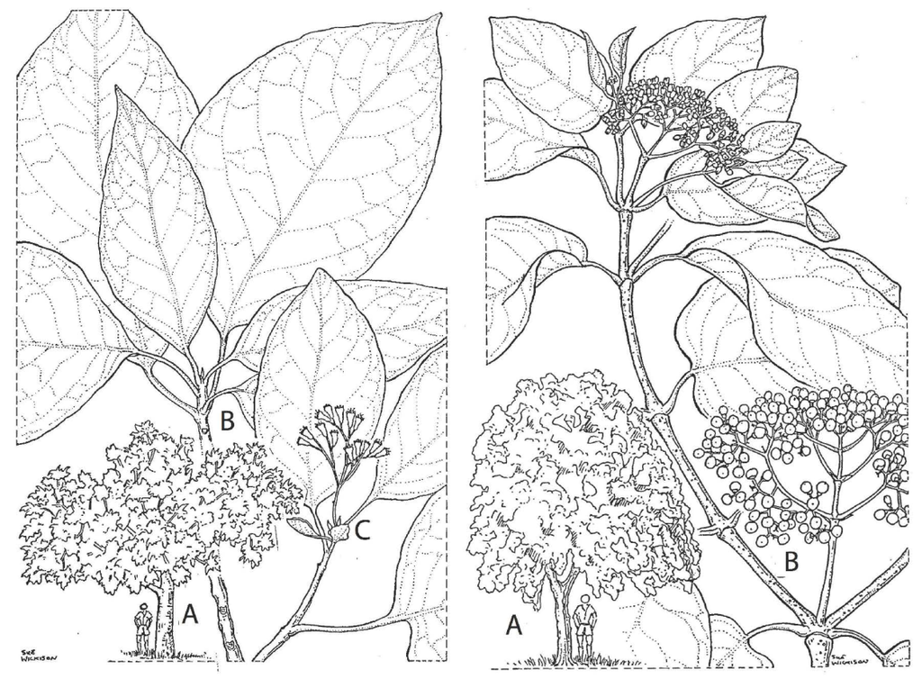

**Figure 5.14:** **Left** *Pisonia grandis*: **A**, tree; **B**, shoot; **C**, flowering shoot with small leaves. Right *Premna corymbosa*: **A**, tree; **B**, flowering shoot with leaves .

### 5.12. *Pongamia pinnata* (syn. *Pongamia glabra*) (Fabaceae)

*Pongamia pinnata* is a beach tree, 5-10 m tall, with white flowers (Peekel 1984: 241). Its crushed roots are sometimes used as fish poison, which explains why the Marovo call it *tuva* (reflecting POc *tupa ‘*Derris* sp.’), as *Derris* is the commonest fish poison in NW Island Melanesia. The Nakanai also used the crushed leaves for medicinal purposes (Floyd 1954, Hviding 2005: 188-149).

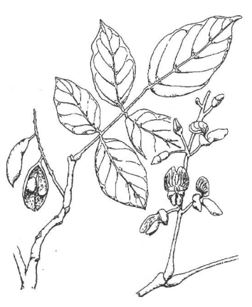

**Figure 5.15:** *Pongamia pinnata*.

The only POc candidate for a name for *Pongamia pinnata* is *pesi. It is clear from the glosses below that it denoted a coastal forest tree (or a taxon of such trees). On the evidence of Wayan Fijian, its PCP reflex denoted a taxon of coastal forest trees, including *Pongamia pinnata* and *Intsia bijuga* (and in Polynesian languages its denotation is limited to the latter). With only one cognate (Teop) outside Central Pacific, it is difficult to know whether the denotatum of *pesi was *Pongamia pinnata* alone, or a taxon as in Wayan.

POLLEX2 and Geraghty (2004: 90) compare PCP *vesi with Malay *besi* ‘iron’ and related forms, but it is unlikely that POc *pesi / PCP *vesi reflects PMP *besi* ‘iron’, as this would give POc †*posi / PCP †*vosi. Geraghty suggests that it reflects a borrowing from a Western Malaya-Polynesian language, but this seems implausible in the light of the evidence below.

| **POc** |  | *pesi | ‘a coastal forest tree, perhaps *Pongamia pinnata*’ |
| --- | --- | --- | --- |
| MM | Teop | *pes* | ‘*Pongamia pinnata*’ |
| **PCP** |  | *vesi | ‘a coastal forest tree taxon including *Pongamia pinnata* and *Intsia bijuga*’ |
| Fij | Bauan | *vesi* | ‘*Intsia bijuga*’ |
| Fij | Wayan | *vesi (wai)* | ‘*Pongamia pinnata*’ |
| Fij | Wayan | *vesi, vesi (dū)* | ‘*Intsia bijuga*’ |
| **PPn** |  | *fesi | ‘*Intsia bijuga*’ |
| Pn | Tongan | *fehi* | ‘*Intsia bijuga*’ |
| Pn | East Uvean | *fesi* | ‘tree from which tapa-cloth beaters made; probably *Intsia bijuga*’ |

### 5.13. *Premna* spp. (Verbenaceae)

Two *Premna* species concern us here. *Premna integrifolia* (syn. *Premna divaricata*) is reported in the Bismarcks, *Premna corymbosa* (syn. *Premna serratifolia*) in the Solomons and Vanuatu (Figure 5.14, right).[^29]: Both are small trees, 4–8 m tall, usually growing immediately behind the beach, although *Premna integrifolia* is reportedly also found in primary forest. At Marovo *Premna corymbosa* grows mainly on coral islets on ocean-facing reefs, typically together with *Pemphis acidula*.

Both *Premna* species tend to branch at the base, with several erect branches, but sometimes they sprawl horizontally. They have hard yellowish wood, white flowers and blue-black to black berries 6–9 mm across, reminiscent of European elderflower and elderberries (Peekel 1984:479, Henderson & Hancock 1988:169-171, Wheatley 1992:244, Kwa’ioloa & Burt 2001: 164, Hviding 2005: 107-108).

Sometimes planted as live fences, *Premna* species provide rafters and fast-burning wood for the cooking fire. They are particularly known, however, for two uses: they provide good wood for traditional fireploughs, and they are commonly used for various medicinal purposes. A common cure for headache is to insert heated leaves and shoots in the nose or to inhale the vapour from a hot infusion. The leaves and shoots are also used to treat pain by rubbing them on the afflicted body part. Arentz et al. (1989: 91) also report that the leaves are boiled and the infusion is drunk against diarrhoea.

| **POc** |  | *qarop | ‘*Premna* spp.’ |
| --- | --- | --- | --- |
| Adm | Mussau | *alo* | ‘tree sp., used for firewood, and traditionally used to make fireploughs’ |
| MM | Varisi | *arovo* | ‘*Premna corymbosa*’ (W. McClatchey, pers. comm.) |
| MM | Babatana | *ɣarovo* | ‘*Premna integrifolia*’ |
| SES | Bugotu | *aro-aro* | ‘*Premna corymbosa*’ (Henderson and Hancock 1988) |
| SES | Kahua | *ʔaro* | ‘*Premna corymbosa*’ (Henderson and Hancock 1988) |
| NCV | Vera’a | *n-ar* | ‘*Premna taitensis*’ (François 2004b) |
| NCV | Mota | *aro* | ‘*Premna taitensis*’ |
| NCV | Raga | *aro* | ‘*Premna* sp.’ (Walsh 2004) |
| Mic | Marshallese | *(ka)ar* | ‘*Premna integrifolia*’ |
| Mic | Puluwatese | *yɔ̄r* | ‘a common tree, possibly *Premna integrifolia*’ |
| Mic | Woleaian | *yāro* | ‘*Premna integrifolia*’ |
| **PCP** |  | *aro-aro | ‘*Premna* spp.’ |
| Fij | Wayan | *ar-aro* | ‘*Premna* spp.’ |
| Fij | Bauan | *yaro-yaro* | ‘*Premna* sp.’ |
| **PPn** |  | *alo-alo | ‘*Premna* sp.’ |
| Pn | Niuean | *alo-alo* | ‘*Premna* sp.’ |
| Pn | Samoan | *alo-alo* | ‘*Premna corymbosa*’ |
| Pn | Samoan | *alo-alo (tai)* | ‘a beach shrub, *Clerodendrum inerme*’ |
| **PPn** |  | *walo-walo | ‘*Premna* spp.’ |
| Pn | East Uvean | *valo-valo* | ‘*Premna taitensis*’ |
| Pn | East Futunan | *valo-valo* | ‘*Premna taitensis*’ |
| Pn | Anutan | *varo-varo* | ‘*Premna integrifolia*’ |
| Pn | Rennellese | *bago-bago* | ‘*Premna gaudichaudii*’ |
| Pn | Ifira-Mele | *varo-varo* | ‘shrub sp.’ |
| Pn | Tikopia | *varo-varo* | ‘*Premna* spp.’ |
| Pn | Tuvalu | *valo-valo* | ‘*Premna taitensis*’ |
| Pn | Nukuoro | *valo-valo* | ‘*Premna integrifolia*’ |
| Pn | Luangiua | *valo-valo* | ‘big tree with fragrant leaves’ |
| Pn | Mangarevan | *varo-varo* | ‘an odorous plant’ |
| Pn | Tahitian | *(a)varo* | ‘*Premna* sp.’ |

cf. also:

| MM | Roviana | *varo* | ‘*Premna integrifolia*’ (borrowing from a Polynesian language?) |
| --- | --- | --- | --- |

## Notes

[^1]: I am grateful to Will McClatchey for elucidating this contrast.
[^2]: Except where otherwise indicated, this introduction is based on material in Mueller-Dombois & Fosberg (1998: 50–70).
[^3]: The form of the reconstruction is puzzling, as it appears to contain the labialised velar *gʷ, but this POc phoneme has not previously been reconstructed. How this should be interpreted is not yet clear.
[^4]: Presumably an *Ipomoea* sp.
[^5]: Presumably an *Ipomoea* sp.
[^6]: Possibly *Ipomoea pes-caprae*.
[^7]: Wolff (1994) argues that this term should not be reconstructed for PMP but started its life somewhere in eastern Indonesia and spread in non-Oceanic languages by borrowing. However, the ACD includes Palauan *kelau* ‘*Cordia* sebestena’, which supports the PMP reconstruction.
[^8]: According to Madulid (2001a: 104) Tagalog *banago*, reflecting PMP *banaRo ‘*Thespesia populnea*’, is used for both species.
[^9]: Gardner & Pawley (2006) record Wayan *vau* for both *Hibiscus tiliaceus* and *Kleinhovia hospita*. This homonymy has arisen through consonant losses in two POc etyma, *paRu ‘*Hibiscus tiliaceus*’ and *paqu ‘*Kleinhovia hospita*’.
[^10]: PMP *ŋiRaj is reconstructed above on the basis of the data here, Palauan *ŋis* ‘*Pemphis acidula*’ (noted by Geraghty 1990) and Ilokano *ŋirad* ‘Pemphis sp.’ (Madulid 2001a).
[^11]: PMP *banaRo is reconstructed on the basis of the Oceanic data here, plus Pangasinan *banaro*, Panay Bisayan *banago*, Hanunuo *banagu*, Kuyonon *banag*, Tagbanwa *banaw*, all ‘*Thespesia populnea*’ (Madulid 2001b: 204).
[^12]: Kwa’ioloa and Burt (2001:123, 132) gloss *milo* as ‘*Elaeocarpus angustifolius*’ and ‘*Trema aspera*’ .
[^13]: Bauan *drala* ‘*Erythrina variegata*’ results from the application to PCP *rara, from POc *rarap, of eastern Fijian apical prenasalisation, a process entailing prenasalisation of the initial apical consonant of a noun following the common noun article *na* (Geraghty 1983: 74–96).
[^14]: The authors of POLLEX assume that PPn *lala ‘*Vitex trifolia*’ reflects the transfer of the term for *Erythrina* variegata to *Vitex trifolia*. As the data here show, this assumption is incorrect.
[^15]: POc *w is lost in NW Solomonic languages; final *-a* is a predictable echo vowel. Kokota *n-* reflects the accreted article POc *na.
[^16]: I am grateful to Will McClatchey for drawing my attention to this possibility.
[^17]: These similarities lead to disagreements among listings of names: an APNI entry identifies *Barringtonia racemosa* with *Barringtonia edulis*, whereas an IPNI entry identifies it with *Barringtonia speciosa* (= asiatica).
[^18]: Initial *vu- here is not related to the prefix *vu-* ‘tree counter’ which occurs in various North Vanuatu languages (ch.2, §7.1.3).
[^19]: Probably borrowed from Fijian (Geraghty 2004: 84).
[^20]: In vol. 1, *asa(q) ‘grate, sharpen’ (ch. 9, §2.1), *asu ‘ladle, bailer’ (ch. 7, §7.4); in vol. 2, *alito(n) ‘firebrand’ (ch. 3, §8.2), *anin ‘wind’ (ch. 5, §4.1), *aparat ‘NW wind’ (ch. 5, §4.2), *api ‘fire’ (ch. 3, §8 .1), *atas ‘top, space above’ (ch. 8, §2.2.6).
[^21]: Nduke and Roviana naru seems to be a borrowing from a (now lost?) language retaining the POc article *na on nouns.
[^22]: PMP *baRbaR is reconstructed on the basis of the Ilokano, Tagalog and Oceanic forms listed here.
[^23]: The final *-am* of Gitua *baram* is unexplained, but the non-Oceanic evidence indicates that it does not reflect part of the POc form.
[^24]: Also sometimes spelled *berteriana* or *berterana* in the literature, but IPNI and APNI give *berteroana*. The species name is derived from the French surname Berteron.
[^25]: Tagbanwa *banayon* (Madulid 2001b: 150) appears to reflect a possible PMP *banayen. If this is ancestral to the forms listed here, then the POc form was *(p,b)an(e)on, with possible deletion of *-e- because the sequence *-eo- was not a part of POc phonotactics.
[^26]: Recorded by Wheatley (1992: 198), but not by Lynch (2004a). Spelling may be incorrect.
[^27]: Recorded by Wheatley (1992: 198), but not by Lynch (2004a). Spelling may be incorrect.
[^28]: This assumes that the terms in the cognate set are all correctly glossed.
[^29]: A third species, *Premna taitensis*, is apparently native to eastern Polynesia.